# ATP Analysis and Prediction

Jorge Moral Fernández

2025-03-02

```r
library(tidyverse)
library(MASS)
library(tidymodels)
library(e1071)
library(ggplot2)
library(effects)
```

# 1 INTRODUCTION

Tennis is a sport that blends skill, strategy, and endurance, making it a fascinating topic to explore through data analysis. This project uses real-world tennis data to examine different aspects of the game and uncover patterns that may not be immediately obvious. The goal is to apply predictive modeling techniques to analyze key areas that influence the world of professional tennis. Specifically, this project will work with data from all professional tennis matches played during the 2023 season. The analysis will focus on identifying patterns and key factors that influenced player performance throughout the year. Using these insights, predictive models will be developed to forecast potential outcomes for other seasons, providing a data-driven perspective on what might shape the upcoming year in professional tennis.

## 1.1 Data set

The data set we will use contains a total of 49 variables, including information about tournament characteristics such as the type of tournament, the playing surface, and details about the winner and loser of each match, along with the respective results.

**Observation:** Instead of splitting a single dataset into two parts to train the model and then predict results, we will use two separate datasets. These datasets, while essentially similar, are differentiated by time: the training dataset consists of the most recent matches (from 2023), while the testing dataset includes matches from the previous year (2022). This approach is due to the point that tennis is highly complex, with tournament conditions varying significantly. To develop a more accurate model, I decided to train it using comprehensive data from each tournament, ensuring that all possible variables are considered.

```r
#READ THE CSV FILES FOR THE TRAIN AND PREDICTION DATASETS
atp_data = read.csv("atp_matches_2023.csv", header = TRUE, stringsAsFactors = FALSE)
atp_data_predict = read.csv("atp_matches_predict.csv", header = TRUE, stringsAsFactors = FALSE)
```

## 1.2 Some data preparation

It is clear that out of the 49 variables, many are not relevant to our study. Some columns in the dataset are ID columns, while others are constant columns. These columns are excluded from our analysis as they do not contribute to building the model or making predictions. Therefore, we will conduct an initial cleaning to retain the most significant variables and provide a brief description of them. Among the 49 total variables, we have decided to retain the following 27 variables, as we consider that these are the main important ones

- **tourney_id**: Unique identifier for the tournament.
- **tourney_name**: Name of the tournament.
- **surface**: Type of surface the tournament is played on (e.g., clay, grass, hard).
- **tourney_level**: The level of the tournament (e.g., Grand Slam, ATP 1000, etc.).
- **winner_id**: Unique identifier of the winning player.
- **winner_name**: Name of the winning player.
- **winner_hand**: Dominant hand of the winning player (right or left).
- **winner_ht**: Height of the winning player in centimeters.
- **winner_ioc**: Country code of the winning player (as per the International Olympic Committee).
- **winner_age**: Age of the winning player at the time of the match.
- **loser_id**: Unique identifier of the losing player.
- **loser_name**: Name of the losing player.
- **loser_hand**: Dominant hand of the losing player (right or left).
- **loser_ht**: Height of the losing player in centimeters.
- **loser_age**: Age of the losing player at the time of the match.
- **score**: The score of the match (e.g., 6-4, 6-3).
- **minutes**: Duration of the match in minutes.
- **w_ace**: Number of aces served by the winning player.
- **w_svpt**: Total number of service points played by the winning player.
- **w_1stIn**: Number of first serves made by the winning player.
- **w_1stWon**: Number of points won on the first serve by the winning player.
- **l_ace**: Number of aces served by the losing player.
- **l_svpt**: Total number of service points played by the losing player.
- **l_1stIn**: Number of first serves made by the losing player.
- **l_1stWon**: Number of points won on the first serve by the losing player.
- **winner_rank**: Ranking of the winning player at the time of the match.
- **loser_rank**: Ranking of the losing player at the time of the match.

```r
#CREATE THE NEW DATASET WITH THE SPECIFIC DATA
ATP_matches = atp_data[ c("tourney_id", "tourney_name", "surface", "tourney_level", "winner_id", "winner_name", "winner_hand", "winner_ht", "winner_ioc", "winner_age", "loser_id", "loser_name", "loser_hand", "loser_ht", "loser_age", "score", "minutes", "w_ace", "w_svpt", "w_1stIn", "w_1stWon", "l_ace", "l_svpt", "l_1stIn", "l_1stWon", "winner_rank", "loser_rank")]

ATP_matches_predict = atp_data_predict[ c("tourney_id", "tourney_name", "surface", "tourney_level", "winner_id", "winner_name", "winner_hand", "winner_ht", "winner_ioc", "winner_age", "loser_id", "loser_name", "loser_hand", "loser_ht", "loser_age", "score", "minutes", "w_ace", "w_svpt", "w_1stIn", "w_1stWon", "l_ace", "l_svpt", "l_1stIn", "l_1stWon", "winner_rank", "loser_rank")]
```

### 1.2.1 Data available

- *Instances available*

```r
# LOOK HOW MANY INSTANCES OUR DATABASE HAS
nrow(ATP_matches)
```

```
## [1] 2242
```

```r
nrow(ATP_matches_predict)
```

```
## [1] 2917
```

Our training dataset contains 2,242 entries, while the dataset used for predictions and evaluating the model’s effectiveness consists of 2,917 entries.

- *Numerical and Categorical variables*

  The first step in our analysis is to distinguish between numerical and categorical variables. It is important to note that certain variables, such as ‘winner_id,’ will be treated as numerical despite being an ID variable. This distinction will be considered in subsequent analyses to ensure accurate interpretation.

```r
#IDENTIFY THE VARIABLE TYPE
ATP_matches <- type.convert(ATP_matches, as.is = TRUE)
variable_types <- sapply(ATP_matches, class)
variable_table <- data.frame(
  Variable = names(variable_types),
  Type = ifelse(variable_types %in% c("numeric", "integer"), "Numeric", "Categorical")
)

# PRINT THE TABLE
print(variable_table, row.names = FALSE)
```

```
##       Variable        Type
##     tourney_id Categorical
##   tourney_name Categorical
##        surface Categorical
##  tourney_level Categorical
##      winner_id     Numeric
##    winner_name Categorical
##    winner_hand Categorical
##      winner_ht     Numeric
##     winner_ioc Categorical
##     winner_age     Numeric
##       loser_id     Numeric
##     loser_name Categorical
##     loser_hand Categorical
##       loser_ht     Numeric
##      loser_age     Numeric
##          score Categorical
##        minutes     Numeric
##          w_ace     Numeric
##         w_svpt     Numeric
##        w_1stIn     Numeric
##       w_1stWon     Numeric
##          l_ace     Numeric
##         l_svpt     Numeric
##        l_1stIn     Numeric
##       l_1stWon     Numeric
##    winner_rank     Numeric
##     loser_rank     Numeric
```

- *Missing values*

  Now, we will analyze whether our dataset is complete or if it contains missing values that need to be addressed.

```r
# IDENTIFY MISSING VALUES IN EACH COLUMN
missing_by_column <- colSums(is.na(ATP_matches))

# TOTAL NUMBER OF MISSING VALUES IN THE DATASET
total_missing <- sum(is.na(ATP_matches))

# COUNT NUMBER OF ROWS WITH AT LEAST ONE MISSING VALUE
rows_with_na <- sum(apply(ATP_matches, 1, function(row) any(is.na(row))))

# CREATE A SUMMARY TABLE WITH MISSING DATA INFORMATION
missing_summary <- data.frame(
  Column = names(missing_by_column),                  # COLUMN NAME
  Missing_Values = missing_by_column,                 # TOTAL MISSING VALUES PER COLUMN
  Total_Values = nrow(ATP_matches),                   # TOTAL ROWS IN THE DATASET
  Missing_Percentage = (missing_by_column / nrow(ATP_matches)) * 100  # PERCENTAGE OF MISSING VALUES
)

# SORT THE SUMMARY TABLE BY THE NUMBER OF MISSING VALUES (DESCENDING)
missing_summary <- missing_summary[order(-missing_summary$Missing_Values), ]

# DISPLAY THE SUMMARY TABLE
print(missing_summary)
```

```
##                      Column Missing_Values Total_Values Missing_Percentage
## minutes             minutes            232         2242         10.3479037
## loser_ht           loser_ht            223         2242          9.9464764
## winner_ht         winner_ht            119         2242          5.3077609
## w_ace                 w_ace            113         2242          5.0401427
## w_svpt               w_svpt            113         2242          5.0401427
## w_1stIn             w_1stIn            113         2242          5.0401427
## w_1stWon           w_1stWon            113         2242          5.0401427
## l_ace                 l_ace            113         2242          5.0401427
## l_svpt               l_svpt            113         2242          5.0401427
## l_1stIn             l_1stIn            113         2242          5.0401427
## l_1stWon           l_1stWon            113         2242          5.0401427
## loser_rank       loser_rank             21         2242          0.9366637
## winner_rank     winner_rank             11         2242          0.4906334
## loser_age         loser_age              4         2242          0.1784121
## tourney_id       tourney_id              0         2242          0.0000000
## tourney_name   tourney_name              0         2242          0.0000000
## surface             surface              0         2242          0.0000000
## tourney_level tourney_level              0         2242          0.0000000
## winner_id         winner_id              0         2242          0.0000000
## winner_name     winner_name              0         2242          0.0000000
## winner_hand     winner_hand              0         2242          0.0000000
## winner_ioc       winner_ioc              0         2242          0.0000000
## winner_age       winner_age              0         2242          0.0000000
## loser_id           loser_id              0         2242          0.0000000
## loser_name       loser_name              0         2242          0.0000000
## loser_hand       loser_hand              0         2242          0.0000000
## score                 score              0         2242          0.0000000
```

- *Correlation between some variables*

[output not shown]

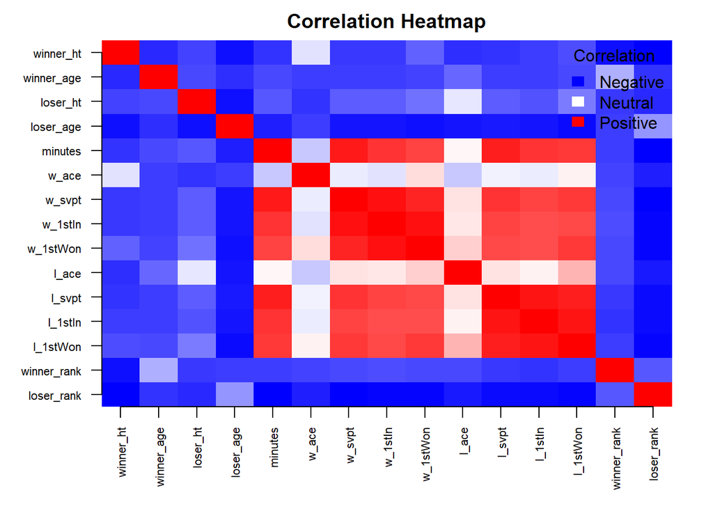

```r
#HEATMAP
par(mar = c(5, 5, 2, 2)) # Set plot margins
image(1:ncol(correlation_matrix), 1:nrow(correlation_matrix), t(correlation_matrix[nrow(correlation_matrix):1, ]),
      col = colorRampPalette(c("blue", "white", "red"))(100), axes = FALSE,
      xlab = "", ylab = "", main = "Correlation Heatmap")

axis(1, at = 1:ncol(correlation_matrix), labels = colnames(correlation_matrix), las = 2, cex.axis = 0.7)
axis(2, at = 1:nrow(correlation_matrix), labels = rev(rownames(correlation_matrix)), las = 2, cex.axis = 0.7)

legend("topright", legend = c("Negative", "Neutral", "Positive"), fill = colorRampPalette(c("blue", "white", "red"))(3),
       border = NA, bty = "n", title = "Correlation")
```

**Explanation** Without going into too much detail, we can observe at first glance that the relationships are strongly polarized into distinct clusters.

# 2 VARIABLE SIGNIFICANCE IN MATCH OUTCOMES

In this initial section, we will conduct a series of analyses to better understand the variables that influence the determination of a winner or loser in a tennis match. By exploring these factors, we aim to identify the key elements that contribute to match outcomes. These preliminary analyses will be particularly useful later in the project, as they will inform the development of a logistic regression model (GLM). This model, which we will explain in detail at the end of the project, will allow us to predict match outcomes based on the characteristics of the players and the surface on which the match is played. By conducting these foundational analyses early on, we will gain valuable insights that will guide the training and prediction process in all the following models.

In the following analyses, we will make a distinction between two cases. The first case will involve considering all the data without taking into account the surface on which the match was played. In the second case, we will include the surface as a factor, as this will allow us to analyze whether it plays a significant role in determining the match outcome, or if, on the other hand, it is irrelevant.

*Observation*: As a tennis player with many years of experience, both watching and competing, I can theorize that the surface plays a more or less important role in determining match outcomes. This is why I will make this distinction in the analysis

## 2.1 Influence of the ranking of each player

### 2.1.1 Without considering the surface

The ranking of each tennis player is based on a points system, where players accumulate points as they win matches. Consequently, a player’s ranking is proportional to their total points, with the number one ranking (and therefore the current best player) held by the player with the highest points at any given time. This suggests that in a match where, for example, the player ranked 7th faces the player ranked 23rd, the better-ranked player is more likely to win, as he is theoretically in better form over the past year.

To conduct this analysis, I will provide an R script that calculates the ranking difference between players. If the difference is positive, it will assign a value of 1, indicating that the player with the higher ranking won. If the difference is negative, it will assign a value of 0, representing a win by the lower-ranked player. Additionally, the script will generate a plot to visualize the number of victories based on whether the higher-ranked or lower-ranked player emerged victorious.

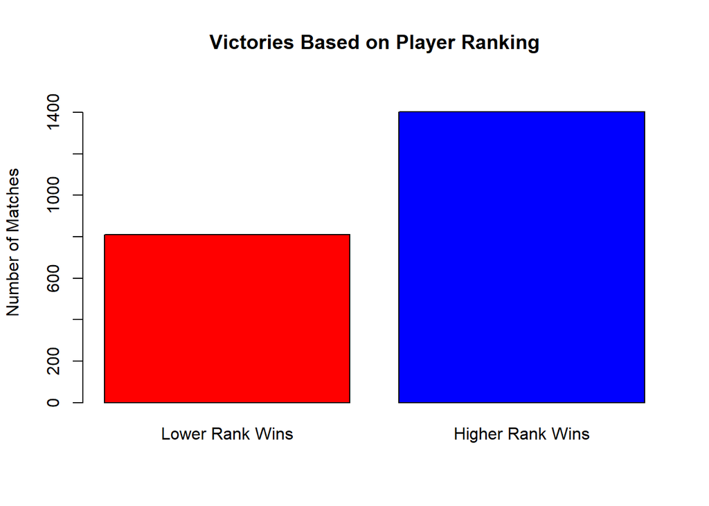

```r
# Difference in ranking
ATP_matches$difference_rank = ATP_matches$loser_rank - ATP_matches$winner_rank

# Binary column: 1 if the difference is positive (so the loser rank is higher(worse) than the winner rank which is lower(better))
ATP_matches$better_rank_wins = ifelse(ATP_matches$difference_rank > 0, 1, 0)

# Count the victories, excluding NA values
victory_counts = table(ATP_matches$better_rank_wins, useNA = "no")

# Plotting
barplot(victory_counts,
        names.arg = c("Lower Rank Wins", "Higher Rank Wins"),
        col = c("red", "blue"),
        main = "Victories Based on Player Ranking",
        ylab = "Number of Matches",
        ylim = c(0, max(victory_counts) * 1.1))
```

```r
proportion_victories <- victory_counts / sum(victory_counts)
proportion_victories
```

```
##
##         0         1
## 0.3664709 0.6335291
```

As we anticipated, it is common for the better-ranked player to win when facing a worse-ranked opponent. We can initially assume that the probability of the player with the better ranking winning the match is approximately 63.3%. This is a very basic analysis that overlooks several key factors. One such factor is the type of surface on which the match is played (clay, hard court, or grass), as tennis can almost be considered a different sport depending on the playing surface. To address this, we will conduct the same analysis but additionally differentiate by the surface on which each match was played.

### 2.1.2 Considering the surface

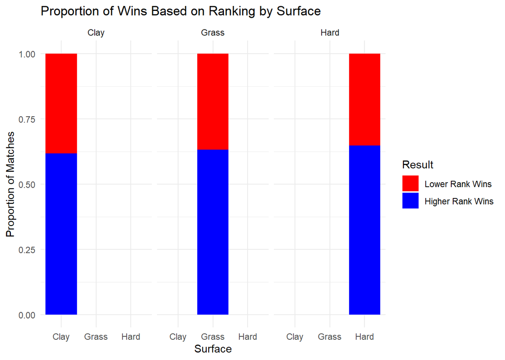

```r
ATP_matches$difference_rank = ATP_matches$loser_rank - ATP_matches$winner_rank
ATP_matches$better_rank_wins = ifelse(ATP_matches$difference_rank > 0, 1, 0)

# Count victories separating by surface
victory_by_surface = table(ATP_matches$better_rank_wins, ATP_matches$surface)

proportion_victories = victory_by_surface / rowSums(victory_by_surface)

ggplot(data = ATP_matches[!is.na(ATP_matches$better_rank_wins) & !is.na(ATP_matches$surface), ],
       aes(x = surface, fill = factor(better_rank_wins))) +
  geom_bar(position = "fill") +
  scale_fill_manual(values = c("red", "blue"), labels = c("Lower Rank Wins", "Higher Rank Wins")) +
  labs(title = "Proportion of Wins Based on Ranking by Surface",
       x = "Surface",
       y = "Proportion of Matches",
       fill = "Result") +
  theme_minimal() +
  facet_wrap(~ surface)
```

```r
proportion_victories = apply(victory_by_surface, 2, function(x) x / sum(x))
proportion_victories
```

```
##
##         Clay     Grass      Hard
##   0 0.381984 0.3679245 0.3526523
##   1 0.618016 0.6320755 0.6473477
```

Here we can observe that the win-loss ratio remains relatively stable, with clay being the surface where the supposed superiority in ranking has the least influence.

## 2.2 Influence of the serve

### 2.2.1 Without considering the surface

During a tennis match, there are key moments that can swing the victory in favor of one player or the other. However, one thing is clear: the player who serves first generally has the advantage, as they initiate the point and have the opportunity to take the lead. This leads to the assumption that players with a strong serve tend to win the most matches. While this is not entirely true, it allows us to analyze whether this statistic holds true or not.

To do this, we will study the effectiveness of players’ serves and whether it contributes to their victory. We will introduce a new variable, which is the percentage of points in which the player serves their first serve. This variable will be calculated as the total number of first serves divided by the total number of service points played.

```r
ATP_matches$first_serve_percentage = ATP_matches$w_1stIn / ATP_matches$w_svpt
head(ATP_matches$first_serve_percentage)
```

```
## [1] 0.6117647 0.7037037 0.6250000 0.6065574 0.5306122 0.6097561
```

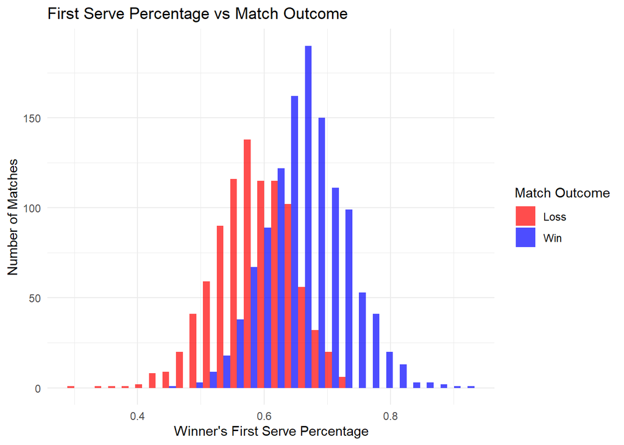

```r
#Percetage of the winner and the loser
ATP_matches$winner_1st_serve_percentage = ATP_matches$w_1stIn / ATP_matches$w_svpt
ATP_matches$loser_1st_serve_percentage = ATP_matches$l_1stIn / ATP_matches$l_svpt

ATP_matches$first_serve_wins = ifelse(ATP_matches$winner_1st_serve_percentage > ATP_matches$loser_1st_serve_percentage, 1, 0)

ggplot(ATP_matches, aes(x = winner_1st_serve_percentage, fill = factor(first_serve_wins))) +
  geom_histogram(position = "dodge", bins = 30, alpha = 0.7) +
  scale_fill_manual(values = c("red", "blue"), labels = c("Loss", "Win")) +
  labs(title = "First Serve Percentage vs Match Outcome",
       x = "Winner's First Serve Percentage",
       y = "Number of Matches",
       fill = "Match Outcome") +
  theme_minimal()
```

As observed in the graph, as the effectiveness of the first serve improves, the total number of victories increases. Additionally, as mentioned earlier, the court surface often has a significant impact on match outcomes. Therefore, we will conduct this analysis while considering the different surfaces: clay, hard court, and grass. We will plot the number of victories on each surface and analyze whether there is any noticeable difference in the impact of first serve effectiveness.

### 2.2.2 Considering the surface

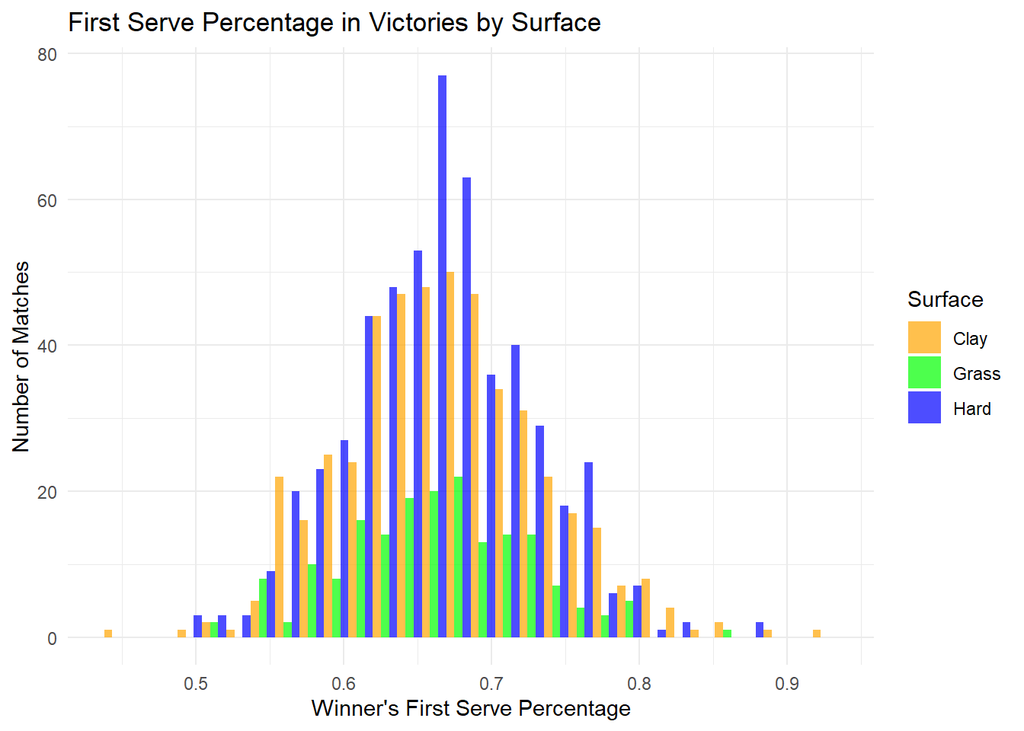

```r
ATP_matches$winner_1st_serve_percentage = ATP_matches$w_1stIn / ATP_matches$w_svpt
ATP_matches$loser_1st_serve_percentage = ATP_matches$l_1stIn / ATP_matches$l_svpt

ATP_matches$first_serve_wins = ifelse(ATP_matches$winner_1st_serve_percentage > ATP_matches$loser_1st_serve_percentage, 1, 0)

ATP_victories = ATP_matches %>% filter(first_serve_wins == 1)

surface_colors = c("Grass" = "green", "Clay" = "orange", "Hard" = "blue")

ggplot(ATP_victories, aes(x = winner_1st_serve_percentage, fill = surface)) +
  geom_histogram(position = "dodge", bins = 30, alpha = 0.7) +
  scale_fill_manual(values = surface_colors) +
  labs(title = "First Serve Percentage in Victories by Surface",
       x = "Winner's First Serve Percentage",
       y = "Number of Matches",
       fill = "Surface") +
  theme_minimal()
```

The distribution across the three surfaces appears to be approximately symmetrical, with a similar mean for the first serve percentage. However, the total number of victories on grass is significantly smaller compared to clay or hard courts, primarily because the grass season is considerably shorter, lasting only about one month each year.

```r
# Percentage of first service
percentage_by_surface = ATP_victories %>% group_by(surface) %>% summarize(mean_first_serve_percentage = mean(winner_1st_serve_percentage, na.rm = TRUE))
percentage_by_surface
```

| surface | mean_first_serve_percentage |
| --- | --- |
| Clay | 0.6719082 |
| Grass | 0.6621605 |
| Hard | 0.6609112 |

### 2.2.3 Comparison between the service performance of each player

We can also examine how the quality of the winner’s service influences the match outcome, specifically by comparing it to the service performance of the losing player. We will conduct a similar analysis to the ranking comparison, plotting the number of matches won by the player with the higher service percentage versus those won by the player with the lower service percentage.

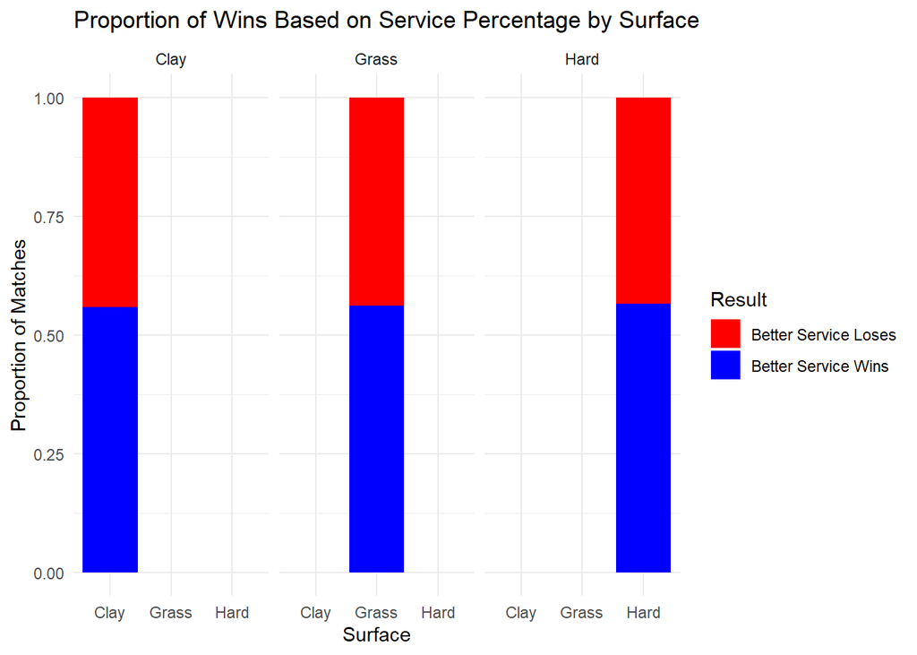

```r
ATP_matches_clean = ATP_matches %>%
  mutate(
    winner_1st_serve_percentage = w_1stIn / w_svpt,
    loser_1st_serve_percentage = l_1stIn / l_svpt
  )

ATP_matches_clean = ATP_matches_clean %>%
  filter(!is.na(winner_1st_serve_percentage), !is.na(loser_1st_serve_percentage))

ATP_matches_clean$better_service_wins <- ifelse(
  ATP_matches_clean$winner_1st_serve_percentage > ATP_matches_clean$loser_1st_serve_percentage,
  "Better Service Wins",
  "Better Service Loses"
)

ggplot(data = ATP_matches_clean, aes(x = surface, fill = factor(better_service_wins))) +
  geom_bar(position = "fill") +
  scale_fill_manual(values = c("red", "blue"), labels = c("Better Service Loses", "Better Service Wins")) +
  labs(title = "Proportion of Wins Based on Service Percentage by Surface",
       x = "Surface",
       y = "Proportion of Matches",
       fill = "Result") +
  theme_minimal() +
  facet_wrap(~ surface)
```

```r
service_proportions <- ATP_matches_clean %>%
  filter(!is.na(surface)) %>%
  group_by(surface) %>%
  mutate(total_matches = n()) %>%
  group_by(surface, better_service_wins) %>%
  summarize(count = n(), total_surface_matches = first(total_matches), .groups = "drop") %>%
  mutate(proportion = (count / total_surface_matches) * 100)

service_proportions
```

| surface | better_service_wins | count | total_surface_matches | proportion |
| --- | --- | --- | --- | --- |
| Clay | Better Service Loses | 377 | 853 | 44.19695 |
| Clay | Better Service Wins | 476 | 853 | 55.80305 |
| Grass | Better Service Loses | 142 | 324 | 43.82716 |
| Grass | Better Service Wins | 182 | 324 | 56.17284 |
| Hard | Better Service Loses | 414 | 952 | 43.48739 |
| Hard | Better Service Wins | 538 | 952 | 56.51261 |

We can observe that players with a higher first service percentage win more than 55% of the matches. This suggests that a better first serve improves the likelihood of winning against opponents. However, the impact, while notable, is not overwhelming, as tennis is a highly complex sport influenced by numerous factors.

## 2.3 Influence of the player’s dominant hand

Another interesting analysis we can conduct is whether there is a significant advantage for left-handed players over right-handed ones. The motivation behind this analysis stems from the story of the tennis player **Rafael Nadal**, who, despite being naturally right-handed, was taught to play with his left hand by his uncle. The reasoning was that left-handed players supposedly have a greater advantage over right-handed ones. Nadal, often regarded as one of the greatest tennis players in history, is considered by many to owe part of his success to his left-handed playstyle. This raises the question of whether there is a clear superiority in being left-handed in tennis. It would be fascinating to explore if there is indeed a noticeable advantage for left-handed players or if it is more about individual skill and style.

### 2.3.1 Without considering the surface

To conduct this analysis, we will focus on matches where a left-handed player competes against a right-handed player. The goal is to determine which group—left-handed or right-handed players—achieves a higher number of victories.

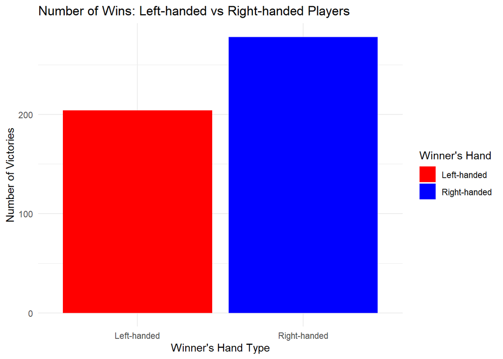

```r
ATP_matches_filtered = ATP_matches %>%
  filter((winner_hand == "L" & loser_hand == "R") | (winner_hand == "R" & loser_hand == "L"))

ATP_matches_filtered$winner_hand_type = ifelse(ATP_matches_filtered$winner_hand == "L", "Left-handed", "Right-handed")

ggplot(ATP_matches_filtered, aes(x = winner_hand_type, fill = winner_hand_type)) +
  geom_bar(stat = "count") +
  scale_fill_manual(values = c("red", "blue"), labels = c("Left-handed", "Right-handed")) +
  labs(title = "Number of Wins: Left-handed vs Right-handed Players",
       x = "Winner's Hand Type",
       y = "Number of Victories",
       fill = "Winner's Hand") +
  theme_minimal()
```

From this graph, it’s clear that being left-handed doesn’t really provide an advantage over being right-handed. However, it would be interesting to see if the surface the match was played on, such as clay, grass, or hard courts, makes any difference.

### 2.3.2 Considering the surface

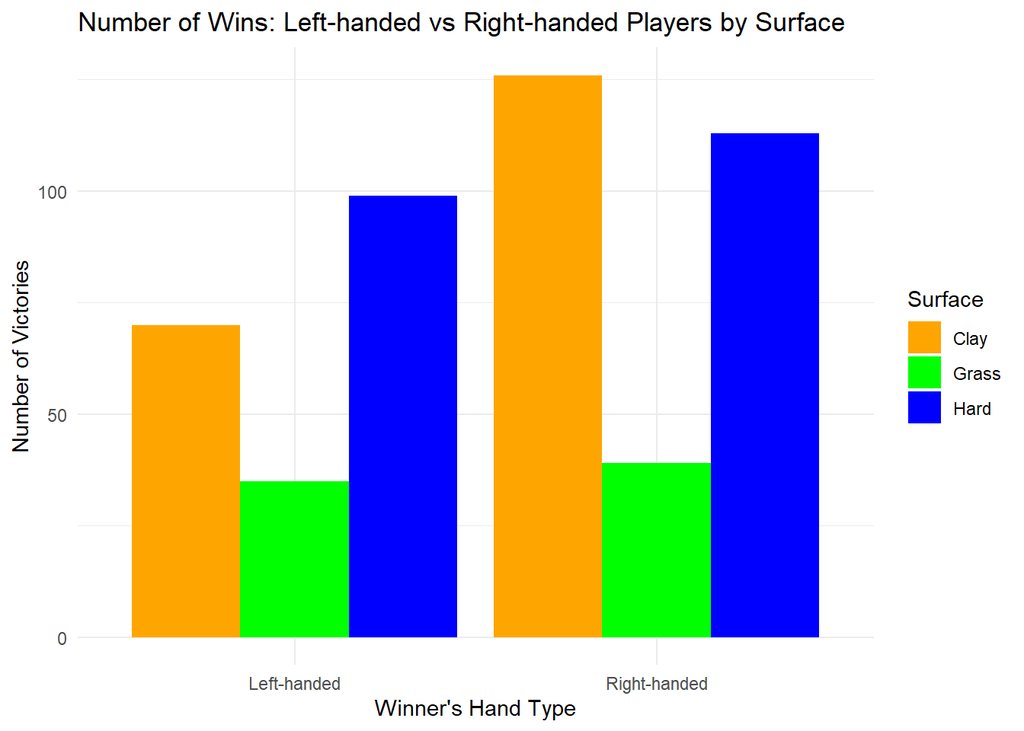

```r
ATP_matches_filtered <- ATP_matches %>%
  filter((winner_hand == "L" & loser_hand == "R") | (winner_hand == "R" & loser_hand == "L"))

ATP_matches_filtered <- ATP_matches_filtered %>%
  mutate(
    winner_hand_type = ifelse(winner_hand == "L", "Left-handed", "Right-handed")
  )

ggplot(ATP_matches_filtered, aes(x = winner_hand_type, fill = surface)) +
  geom_bar(stat = "count", position = "dodge") +
  scale_fill_manual(
    values = c("Clay" = "orange", "Grass" = "green", "Hard" = "blue"),
    labels = c("Clay", "Grass", "Hard")
  ) +
  labs(
    title = "Number of Wins: Left-handed vs Right-handed Players by Surface",
    x = "Winner's Hand Type",
    y = "Number of Victories",
    fill = "Surface"
  ) +
  theme_minimal()
```

After analyzing the surface the match was played on, it becomes clear that left-handed players face a noticeable disadvantage on clay courts. However, on hard courts and grass courts, there doesn’t seem to be any significant disadvantage for left-handed players. This is quite interesting because, despite the clear disadvantage often associated with being left-handed on clay courts, Rafael Nadal, widely considered the greatest clay court player in history, is left-handed. This suggests that Nadal’s advantage and level of success are more closely related to his playing style rather than his dominant hand.

```r
ATP_matches_filtered <- ATP_matches %>%
  filter((winner_hand == "L" & loser_hand == "R") | (winner_hand == "R" & loser_hand == "L")) %>%
  filter(!is.na(surface))

ATP_matches_filtered <- ATP_matches_filtered %>%
  mutate(victory = ifelse(winner_hand == "L", "Left-handed Wins", "Right-handed Wins"))

victories_losses_by_surface <- ATP_matches_filtered %>%
  group_by(surface, victory) %>%
  count() %>%
  group_by(surface) %>%
  mutate(proportion = n / sum(n) * 100) %>%
  ungroup()

victories_losses_by_surface
```

| surface | victory | n | proportion |
| --- | --- | --- | --- |
| Clay | Left-handed Wins | 70 | 35.71429 |
| Clay | Right-handed Wins | 126 | 64.28571 |
| Grass | Left-handed Wins | 35 | 47.29730 |
| Grass | Right-handed Wins | 39 | 52.70270 |
| Hard | Left-handed Wins | 99 | 46.69811 |
| Hard | Right-handed Wins | 113 | 53.30189 |

## 2.4 Influence of other characteristics

The objective of the following section is to perform a deeper analysis of additional characteristics that are also relevant during matches. Since these characteristics are not included in our main dataset, we need to obtain them from other sources. In this case, we will extract the new data from [Ultimate Tennis Statistics](https://www.ultimatetennisstatistics.com/). The challenge is that each new statistic comes in a separate CSV file. Therefore, we must merge the various CSVs, ensuring that the data aligns correctly despite the players not being ordered and the presence of missing information.

Once we have merged the different datasets, we can load our final dataset, called ‘Tennis_Stats,’ which contains additional statistics for nearly 250 top-ranked tennis players. Some of the statistics included are as follows.

```r
Tennis_Stats = read.csv("Tennis_Stats.csv", header = TRUE, stringsAsFactors = FALSE)
nrow(Tennis_Stats)
```

```
## [1] 245
```

**NEW VARIABLES**

- **Avg Unforced Errors**: The average number of unforced errors made by a player per match.
- **Avg Winners**: The average number of winners hit by a player per match.
- **First Serve Avg Return**: The average success rate of returning an opponent’s first serve.
- **First Serve Avg Speed**: The average speed of a player’s first serve.
- **Return Rating**: %1st serve return points won + %2nd serve return points won +%Break points converted + %Return games won
- **Second Serve Avg Return**: The average success rate of returning an opponent’s second serve.
- **Second Serve Avg Speed**: The average speed of a player’s second serve.
- **Service Rating**: %Aces + %Doble faults + %1st serve + % 1st serve points won + %2nd serve points won + %Break points saved + %Service games won.

*Observations:* We can observe by analything this new dataset that some information is missing due to the incomplete nature of the different databases. Therefore, it is important to carefully consider which analyses can be performed and what data is actually available.

### 2.4.1 Player classification

Once we have gathered all the new data, we can begin analyzing aspects that were previously unavailable. For instance, with this data, we can categorize tennis players into three groups:

- ‘aggressive’ = The player makes a high number of winners and unforced errors (‘winners’+‘errors’ > 50%)
- ‘consistent’ = The player shows a mix of aggressive and defensive play, with a moderate number of winners and unforced errors ( 30%<‘winners’+‘errors’ <50%)
- ‘defensive’ = The player plays mainly defensive so he does few unforced errors and few winners (‘winners’+‘errors’ < 30%)

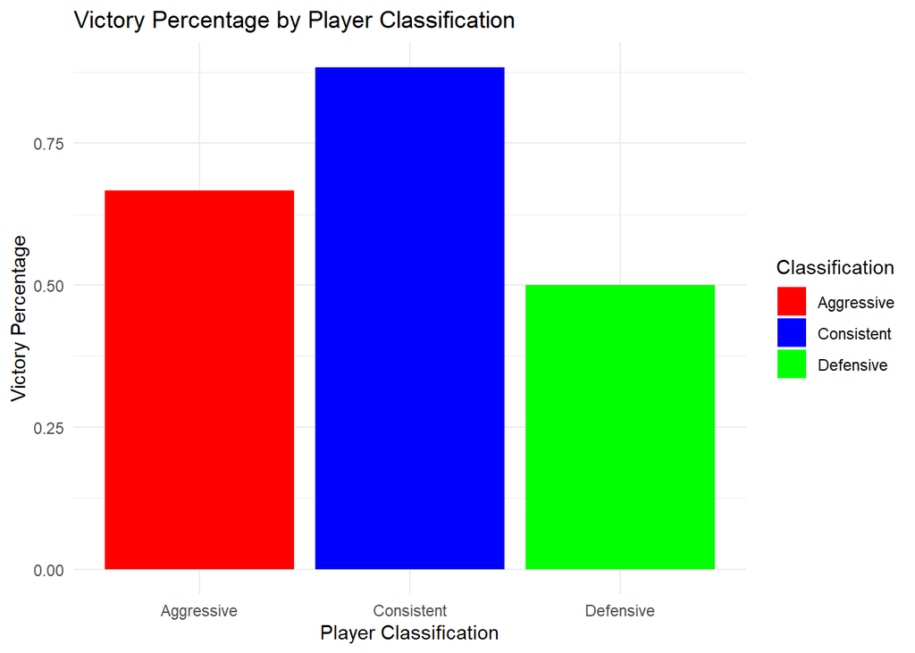

```r
# Filer the columns of Tennis_Stats
Tennis_Stats_filtered <- Tennis_Stats[, c("name", "value_winners", "value_unforced_errors")]

# The columns are percentages so we need to delete the symbol '%' (cleaning)
Tennis_Stats_filtered$value_winners <- as.numeric(gsub("%", "", Tennis_Stats_filtered$value_winners)) / 100
Tennis_Stats_filtered$value_unforced_errors <- as.numeric(gsub("%", "", Tennis_Stats_filtered$value_unforced_errors)) / 100

# Remove rows where there are players with missing information (cleaning)
Tennis_Stats_filtered <- Tennis_Stats_filtered %>%
  filter(!is.na(value_winners) & !is.na(value_unforced_errors))

# Add the percentage of winners and errors
Tennis_Stats_filtered$winners_plus_errors <- Tennis_Stats_filtered$value_winners + Tennis_Stats_filtered$value_unforced_errors

# Classify the players into the different categories
Tennis_Stats_filtered$classification <- ifelse(Tennis_Stats_filtered$winners_plus_errors > 0.5, "Aggressive",
                                               ifelse(Tennis_Stats_filtered$winners_plus_errors < 0.3, "Defensive", "Consistent"))

# Sum the number of victories and defeats of each player
victories <- ATP_matches %>%
  group_by(winner_name) %>%
  summarise(victories = n()) %>%
  rename(name = winner_name)

defeats <- ATP_matches %>%
  group_by(loser_name) %>%
  summarise(defeats = n()) %>%
  rename(name = loser_name)

# Join the data
Tennis_Stats_filtered <- Tennis_Stats_filtered %>%
  left_join(victories, by = "name") %>%
  left_join(defeats, by = "name")

Tennis_Stats_filtered$victories[is.na(Tennis_Stats_filtered$victories)] <- 0
Tennis_Stats_filtered$defeats[is.na(Tennis_Stats_filtered$defeats)] <- 0

# Calculate the percentage of victories
Tennis_Stats_filtered$victory_percentage <- Tennis_Stats_filtered$victories / (Tennis_Stats_filtered$victories + Tennis_Stats_filtered$defeats)

# Plot the percentage of victories depending on the player classification
ggplot(Tennis_Stats_filtered, aes(x = classification, y = victory_percentage, fill = classification)) +
  geom_bar(stat = "identity", position = "dodge") +
  labs(title = "Victory Percentage by Player Classification",
       x = "Player Classification",
       y = "Victory Percentage",
       fill = "Classification") +
  scale_fill_manual(values = c("red", "blue", "green")) +
  theme_minimal()
```

*Observation (Important) :*

At first glance, this result may seem confusing due to the high percentages. The sum of the three percentages should not exceed 1, as when one player wins, the other loses, meaning the total percentage should remain balanced. The issue lies in the fact that, as previously mentioned, our database ‘Tennis_stats’ is incomplete. It only includes data from top-ranked and more prominent players, but not from every player who participated in a professional tournament (this are all the players form ‘ATP_matches’). As a result, the top-ranked players, who are the ones included in our statistics, tend to win more matches than they lose. Since many of the players who lose are not classified by their playing style, this leads to inflated victory percentages. Nevertheless, this analysis remains valuable, as it allows us to observe that, to some extent, consistent players at the top of the world rankings tend to be more effective than those who play aggressively or defensively.

# 3 LINEAR REGRESSION

In this section, we will focus on building two linear regression models to analyze and predict two different variables. The first model will study and analyze the duration of tennis matches, identifying the factors that influence whether a match is short or long. The second model will focus on the number of games each player wins by the end of the match.

## 3.1 Model 1: Duration of a match

When organizing tournaments, it is essential to consider the potential durations of the matches to effectively manage the playing schedules and available courts. In our case, we will analyze how the match duration (**‘minutes’**) relates to the type of surface the match is played on (**‘surface’**), the ages of the players (**‘winner_age’** and **‘loser_age’**), the rankings of the competing players (**‘winner_rank’** and **‘loser_rank’**), the match outcome (**‘score’**), and the tournament level (**‘tourney_level’**).

### 3.1.1 Understanding the ‘target’ variable and the other variables

In this section, we will explore the ‘target’ variable, which represents the duration of the match in minutes, and the other variables in the dataset that will be used to inform the predictions. Understanding the role and distribution of these variables is crucial for building an effective model.

*Visualization of minutes (match duration)*

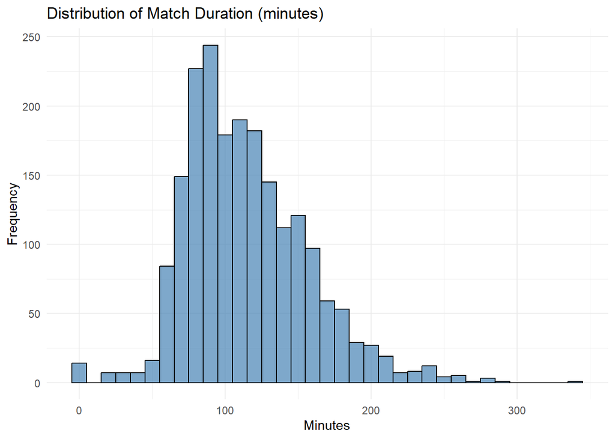

```r
# VISUALIZE THE DURATION OF THE DIFFERENT MATCHES
ggplot(ATP_matches, aes(x = minutes)) +
  geom_histogram(binwidth = 10, fill = "steelblue", color = "black", alpha = 0.7) +
  labs(title = "Distribution of Match Duration (minutes)",
       x = "Minutes",
       y = "Frequency") +
  theme_minimal()
```

*Visualization of minutes by surface*

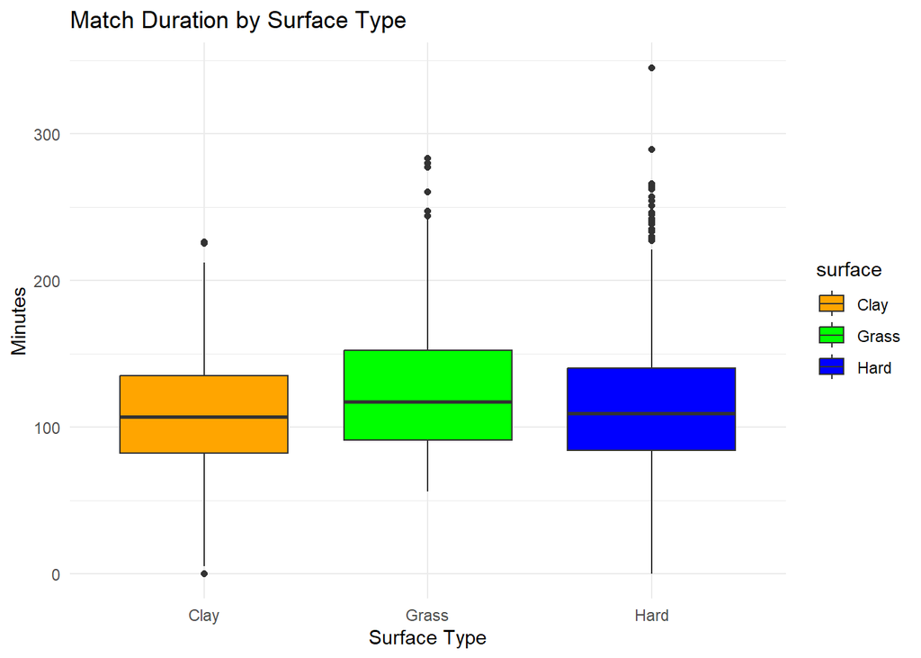

```r
# BOXPLOT OF THE DURATION OF THE MATCHES BY SURFACE
ggplot(ATP_matches, aes(x = surface, y = minutes, fill = surface)) +
  geom_boxplot() +
  labs(title = "Match Duration by Surface Type",
       x = "Surface Type",
       y = "Minutes") +
  theme_minimal() +
  scale_fill_manual(values = c("Hard" = "blue", "Grass" = "green", "Clay" = "orange"))
```

In this boxplot, we can observe that matches played on grass courts tend to have a longer duration. This is quite unusual, as grass courts are generally considered the fastest on the circuit, promoting aggressive play and typically resulting in shorter match durations. Therefore, this outcome seems counterintuitive at first.

The issue arises from the fact that we are not distinguishing between the type of tournament being played, specifically the ‘tourney_level’. In Grand Slam tournaments (such as Wimbledon), matches are played in a best-of-five sets format, unlike most other tournaments, which follow a best-of-three sets format. When combined with the fact that the grass court season is short, meaning a large proportion of grass court matches come from Wimbledon, we have a clearer understanding of why the duration of these matches is longer.

*Visualization of minutes by surface and tourney_level*

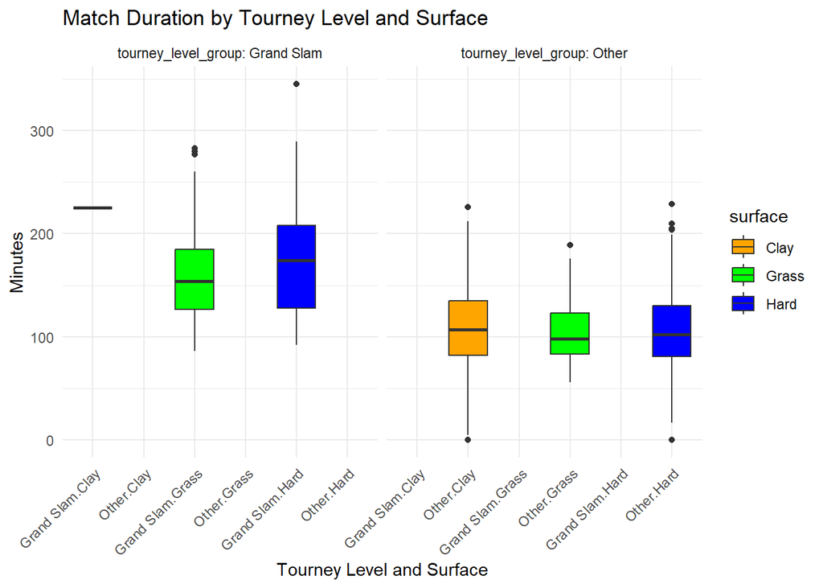

```r
# FILTER THE DATA FORM GRAND SLAMS (G)
ATP_matches$tourney_level_group <- ifelse(ATP_matches$tourney_level == "G", "Grand Slam", "Other")

# Create the boxplot of match duration by surface and tourney_level_group (Grand Slam vs Other)
ggplot(ATP_matches, aes(x = interaction(tourney_level_group, surface), y = minutes, fill = surface)) +
  geom_boxplot() +
  labs(title = "Match Duration by Tourney Level and Surface",
       x = "Tourney Level and Surface",
       y = "Minutes") +
  theme_minimal() +
  scale_fill_manual(values = c("Hard" = "blue", "Grass" = "green", "Clay" = "orange")) +
  facet_wrap(~tourney_level_group, labeller = label_both) +
  theme(axis.text.x = element_text(angle = 45, hjust = 1))
```

From this chart, we can draw several important conclusions. The first is that, as we noted in the previous section, it was strange that grass court matches appeared to last longer. However, we have now confirmed that not all factors were being considered. By accounting for these factors, we can see that both in Grand Slam matches (best of 5 sets) and regular matches (best of 3 sets), the shortest matches tend to be played on grass courts, whereas matches on clay courts tend to be longer. This difference is particularly notable in best-of-5-set matches compared to best-of-3-set matches.

The second conclusion, although somewhat obvious, is that Grand Slam matches last on average much longer than regular matches, as they are played in a best-of-5-sets format. This format requires more games (and sets) to win, thus increasing the overall match duration.

**Observation** In our graph, we can see that the match duration for Grand Slam matches on clay courts (Roland Garros) is represented by only a single line. This is because our dataset is incomplete, containing only one match with recorded duration data. While this result is not particularly significant, it allows us to make some assumptions for the subsequent analyses.

```r
# Filter the only Roland Garros match where 'minutes' is not NA.
roland_garros_match <- ATP_matches[ATP_matches$tourney_name == "Roland Garros" & !is.na(ATP_matches$minutes), ]
print(roland_garros_match)
```

```
##      tourney_id  tourney_name surface tourney_level winner_id    winner_name
## 1402   2023-520 Roland Garros    Clay             G    132283 Lorenzo Sonego
##      winner_hand winner_ht winner_ioc winner_age loser_id    loser_name
## 1402           R       191        ITA         28   126094 Andrey Rublev
##      loser_hand loser_ht loser_age                  score minutes w_ace w_svpt
## 1402          R      188      25.6 5-7 0-6 6-3 7-6(5) 6-3     225     8    157
##      w_1stIn w_1stWon l_ace l_svpt l_1stIn l_1stWon winner_rank loser_rank
## 1402     105       76     9    135      73       55          48          7
##      difference_rank better_rank_wins first_serve_percentage
## 1402             -41                0              0.6687898
##      winner_1st_serve_percentage loser_1st_serve_percentage first_serve_wins
## 1402                   0.6687898                  0.5407407                1
##      tourney_level_group
## 1402          Grand Slam
```

### 3.1.2 Data filtering and cleaning

In this section, we will primarily focus on cleaning the ‘score’ variable. Initially, we interpreted ‘score’ as a qualitative variable, which, although reasonable, is not the most optimal approach. The results of a tennis match are given by sets; for example, a score of 6-3 6-4 indicates that the first player won the first set 6-3 and the second set 6-4. In the case of a tie in sets, a third set would be played, resulting in a score like 6-3 4-6 6-2.

The problem is that these values cannot be directly interpreted or compared to analyze their relationship with the ‘minutes’ variable (match duration). Therefore, our first step will be to create three new variables: **‘winner_games’**, **‘loser_games’**, and **‘total_games’**. These variables will represent the number of games won by each player throughout the match and the total number of games played in the match.

To achieve this, we will develop a function that, given the score of a match (e.g., “6-4 7-5”), splits the results by set and calculates the total number of games won by each player. The function will also account for matches that were not completed due to player retirement or other reasons. Finally, we will sum the number of games both players have done in a new variable called *total_games* that will represent the total amount of games played during the match*.*

```r
# Function to extract the games won by the winner or loser
extract_games <- function(score, type = "winner") {
  # Handle NA, empty values, or walkover (W/O)
  if (is.na(score) || score == "" || grepl("W/O", score)) {
    return(0)  # Return 0 if score is empty or walkover
  }

  # Remove RET and any content inside parentheses (e.g., tiebreak scores)
  clean_score <- gsub("\\(.*?\\)|RET", "", score)

  # Remove any "0-0" from the sets (which usually indicates a retirement or error)
  clean_score <- gsub("0-0", "", clean_score)

  # Check if the format is valid (e.g., "6-3", "7-6(2)", etc.)
  valid_format <- grepl("^\\d+-\\d+( \\d+-\\d+)*$", clean_score)

  if (!valid_format) {
    return(0)  # If the format is not valid, return 0 games
  }

  # Split the sets by space
  sets <- strsplit(clean_score, " ")[[1]]

  # Initialize counters
  winner_games <- 0
  loser_games <- 0

  # Loop over each set
  for (set in sets) {
    # Split the set by hyphen
    games <- strsplit(set, "-")[[1]]

    # If the set is "0-0 RET", only count the first set
    if (length(games) == 2 && games[1] == "0" && games[2] == "0") {
      next  # If it's "0-0", skip this set and do not count
    }

    # If it's a valid set (not 0-0 RET), count the games
    if (length(games) == 2) {
      winner <- as.numeric(games[1])
      loser <- as.numeric(games[2])

      # If both values are numeric, accumulate the games
      if (!is.na(winner) && !is.na(loser)) {
        if (type == "winner") {
          winner_games <- winner_games + winner
        } else {
          loser_games <- loser_games + loser
        }
      }
    }
  }

  # Return the total accumulated games for winner or loser
  if (type == "winner") {
    return(winner_games)
  } else {
    return(loser_games)
  }
}
```

```r
# Apply the function to the dataset
ATP_matches$winner_games <- sapply(ATP_matches$score, extract_games, type = "winner")
ATP_matches$loser_games <- sapply(ATP_matches$score, extract_games, type = "loser")
ATP_matches$total_games = ATP_matches$winner_games + ATP_matches$loser_games
ATP_matches <- ATP_matches[ATP_matches$total_games != 0, ]

# Inspect the results
head(ATP_matches[c("score", "winner_games", "loser_games","total_games")])
```

|  | score | winner_games | loser_games | total_games |
| --- | --- | --- | --- | --- |
| 1 | 7-6(4) 7-6(6) | 14 | 12 | 26 |
| 3 | 7-6(5) 7-6(5) | 14 | 12 | 26 |
| 4 | 6-3 6-3 | 12 | 6 | 18 |
| 5 | 4-6 7-6(2) 6-4 | 17 | 16 | 33 |
| 6 | 6-1 6-1 | 12 | 2 | 14 |
| 7 | 6-0 6-7(4) 7-5 | 19 | 12 | 31 |

We also need to transform our categorical variables, such as the **surface** and **tourney_level**, to make them suitable for analysis.

```r
# Surface and tourney_level are categorical so we have to transform them
ATP_matches$surface <- as.factor(ATP_matches$surface)
ATP_matches$tourney_level <- as.factor(ATP_matches$tourney_level)
```

Now, we will calculate and create a graph to visualize the correlation between the variables of interest and our target variable, **‘minutes’**. As we observed in the initial analyses, the surface on which the match is played and the type of tournament are also critical factors in determining the duration of a tennis match. Therefore, these two variables will also be included in our regression model.

```r
# Exclude winner_id and loser_id from numeric variables
numeric_vars <- names(ATP_matches)[sapply(ATP_matches, is.numeric)]
numeric_vars <- setdiff(numeric_vars, c("winner_id", "loser_id"))

# Select only numeric data
numeric_data <- subset(ATP_matches, select = numeric_vars)

# Calculate correlation matrix
cor_matrix <- cor(numeric_data, use = "complete.obs")

# Extract correlation of 'minutes' with other variables
cor_minutes <- cor_matrix["minutes", -which(colnames(cor_matrix) == "minutes")] # Exclude 'minutes' itself

# Convert to a data frame for visualization
cor_df <- data.frame(variable = names(cor_minutes), correlation = cor_minutes)

# View the correlation data frame
print(cor_df)
```

```
##                                                variable  correlation
## winner_ht                                     winner_ht  0.005256962
## winner_age                                   winner_age  0.054693471
## loser_ht                                       loser_ht  0.069534729
## loser_age                                     loser_age -0.039554853
## w_ace                                             w_ace  0.309173376
## w_svpt                                           w_svpt  0.928745267
## w_1stIn                                         w_1stIn  0.878726647
## w_1stWon                                       w_1stWon  0.836927165
## l_ace                                             l_ace  0.443580594
## l_svpt                                           l_svpt  0.921350637
## l_1stIn                                         l_1stIn  0.878708248
## l_1stWon                                       l_1stWon  0.867492952
## winner_rank                                 winner_rank  0.031122873
## loser_rank                                   loser_rank -0.112957637
## difference_rank                         difference_rank -0.114668794
## better_rank_wins                       better_rank_wins -0.098505253
## first_serve_percentage           first_serve_percentage  0.004891673
## winner_1st_serve_percentage winner_1st_serve_percentage  0.004891673
## loser_1st_serve_percentage   loser_1st_serve_percentage  0.093018974
## first_serve_wins                       first_serve_wins -0.047530420
## winner_games                               winner_games  0.853323450
## loser_games                                 loser_games  0.903585068
## total_games                                 total_games  0.917919670
```

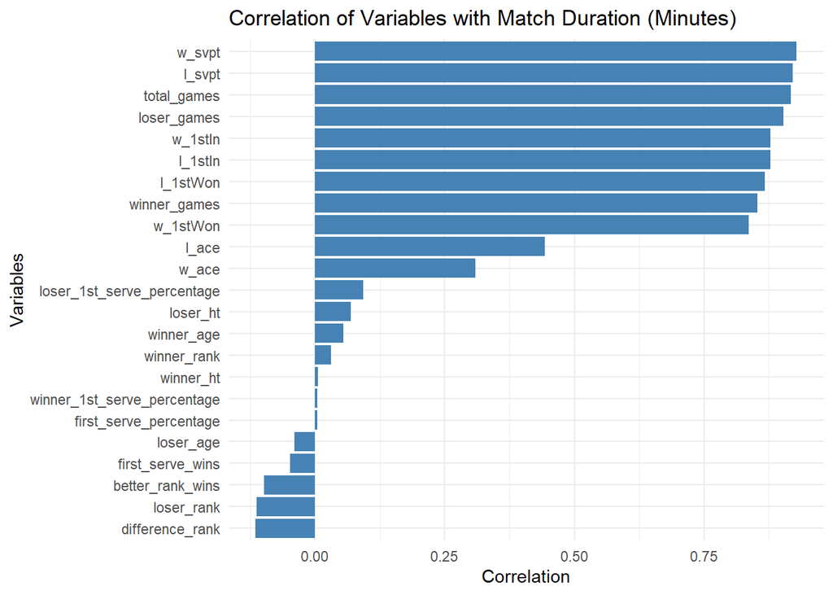

```r
# Plot correlations using ggplot2
library(ggplot2)
ggplot(cor_df, aes(x = reorder(variable, correlation), y = correlation)) +
  geom_bar(stat = "identity", fill = "steelblue") +
  coord_flip() +
  labs(title = "Correlation of Variables with Match Duration (Minutes)",
       x = "Variables", y = "Correlation") +
  theme_minimal()
```

As we can observe, the variables most strongly related to match duration are those associated with the number of points played. The most relevant variables are **winner_games**, **loser_games**, and **total_games**, as other variables are directly linked to them. A clear example is **W_svpt**, which represents the total points played on serve. It is evident that the more games played in total, the more points are played on serve, creating a direct relationship that increases the match duration.

We must also consider the categorical variables, such as the type of surface and the tournament level, which we have already identified as significant factors. To illustrate this, we will present a graph showing the relationship between match duration and the total number of games played, differentiated by playing surface. This graph captures the interaction between duration, surface, and tournament type, as Grand Slam matches are expected to involve a higher total number of games.

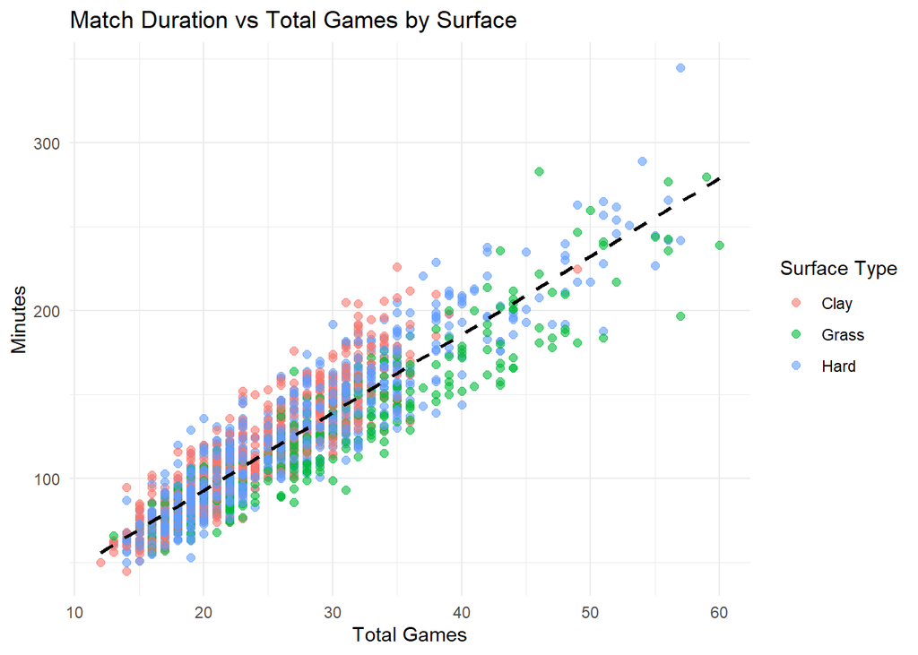

```r
#RELATION BETWEEN NUMBER OF GAMES AND MATCH DURATION
ggplot(ATP_matches, aes(x = total_games, y = minutes, color = surface)) +
  geom_point(alpha = 0.6, size = 2) +
  geom_smooth(method = "lm", se = FALSE, color = "black", linetype = "dashed") +
  labs(title = "Match Duration vs Total Games by Surface",
       x = "Total Games",
       y = "Minutes",
       color = "Surface Type") +
  theme_minimal()
```

We can observe that, unlike matches on clay and hard courts, where there is no clear distinction in match duration, matches played on grass (such as those at Wimbledon) tend to be shorter compared to matches with the same number of total games. This has been previously mentioned and is attributed to the aggressive playing style that grass courts encourage.

### 3.1.3 **Linear Regression**

Now, we can build our regression model using some of the variables we have presented previously.

```r
#LINEAR REGRESION:

variables = c("surface", "winner_age", "loser_age", "winner_rank", "loser_rank", "tourney_level","total_games")
numeric_data = subset(ATP_matches, select = c("minutes", variables))
# Fit the linear regression model
lm_model <- lm(minutes ~ ., data = numeric_data)
# Summary of the regression model
summary(lm_model)
```

```
##
## Call:
## lm(formula = minutes ~ ., data = numeric_data)
##
## Residuals:
##     Min      1Q  Median      3Q     Max
## -62.933  -9.889  -0.889   8.835  78.010
##
## Coefficients:
##                  Estimate Std. Error t value Pr(>|t|)
## (Intercept)     -9.888061   3.354410  -2.948  0.00324 **
## surfaceGrass   -12.963196   1.123827 -11.535  < 2e-16 ***
## surfaceHard     -4.162477   0.764835  -5.442 5.93e-08 ***
## winner_age       0.192906   0.081400   2.370  0.01789 *
## loser_age        0.083499   0.078747   1.060  0.28912
## winner_rank     -0.007169   0.004522  -1.585  0.11303
## loser_rank      -0.005160   0.002913  -1.771  0.07667 .
## tourney_levelG  -8.505330   1.345558  -6.321 3.22e-10 ***
## tourney_levelM  -0.209948   0.816476  -0.257  0.79710
## total_games      4.988519   0.053958  92.452  < 2e-16 ***
## ---
## Signif. codes:  0 '***' 0.001 '**' 0.01 '*' 0.05 '.' 0.1 ' ' 1
##
## Residual standard error: 14.95 on 1923 degrees of freedom
##   (233 observations deleted due to missingness)
## Multiple R-squared:  0.862,  Adjusted R-squared:  0.8613
## F-statistic:  1334 on 9 and 1923 DF,  p-value: < 2.2e-16
```

**Explanation of the main results obtained**

**surface**: The coefficient for the `surfaceGrass` variable is **-12.9**, indicating that matches played on grass courts tend to be shorter than matches played on clay courts. This effect is highly significant with a p-value of **< 2e-16**. This outcome was expected, as grass courts are renowned for their speed, resulting in shorter points due to the more direct and aggressive style of play typically favored on this surface. Additionally, comparing also to Hard courts we can conclude that matches played on clay courts tend to have a slower pace, as the surface reduces the ball’s speed, making it easier for players to maintain rallies. Consequently, points take longer to conclude.

**total_games**: The coefficient for `total_games` is **4.9**, and it is highly significant with a p-value of **< 2e-16**. This suggests that as the number of games played in a match increases, the duration of the match increases as well. Each additional game in the match contributes approximately 4.9 minutes to the total match time. As noted earlier, an increase in the number of games played leads to a longer match duration.

**R-squared**

The R² value of our model is 0.86, indicating that the model explains 86% of the variability observed in the data

### 3.1.4 Prediction

The first step before making predictions with the model is to clean the *ATP_matches_predict* database so that it contains the same variables as our initial dataset.

```r
#Cleaning the predIct database
#WE ONLY PREDICT WITH 20% OF OUR NEW DATABASE BECAUSE IT HAS MANY VALUES
set.seed(123)
ATP_matches_predict <- ATP_matches[sample(1:nrow(ATP_matches), size = 0.2 * nrow(ATP_matches)), ]
ATP_matches_predict <- subset(ATP_matches_predict, tourney_level != "F")
ATP_matches_predict <- subset(ATP_matches_predict, tourney_level != "D")
ATP_matches_predict$winner_games <- sapply(ATP_matches_predict$score, extract_games, type = "winner")
ATP_matches_predict$loser_games <- sapply(ATP_matches_predict$score, extract_games, type = "loser")
ATP_matches_predict$total_games = ATP_matches_predict$winner_games + ATP_matches_predict$loser_games
ATP_matches_predict$surface <- as.factor(ATP_matches_predict$surface)
ATP_matches_predict$tourney_level <- as.factor(ATP_matches_predict$tourney_level)
ATP_matches_predict <- ATP_matches_predict[ATP_matches_predict$total_games != 0, ]
```

```r
#PREDICT
ATP_matches_predict$predicted_minutes <- predict(lm_model, newdata = ATP_matches_predict)

error = ATP_matches_predict$minutes-ATP_matches_predict$predicted_minutes
```

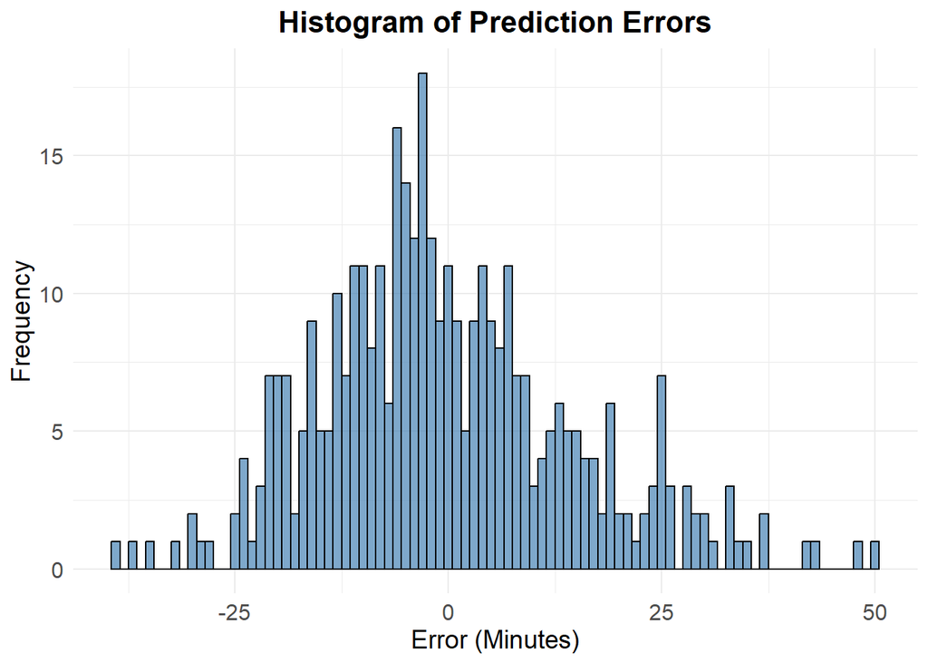

```r
#HISTOGRAM
ggplot(data.frame(error), aes(x = error)) +
  geom_histogram(binwidth = 1, fill = "steelblue", color = "black", alpha = 0.7) +
  labs(title = "Histogram of Prediction Errors",
       x = "Error (Minutes)",
       y = "Frequency") +
  theme_minimal() +
  theme(plot.title = element_text(hjust = 0.5, size = 16, face = "bold"),
        axis.title = element_text(size = 14),
        axis.text = element_text(size = 12))
```

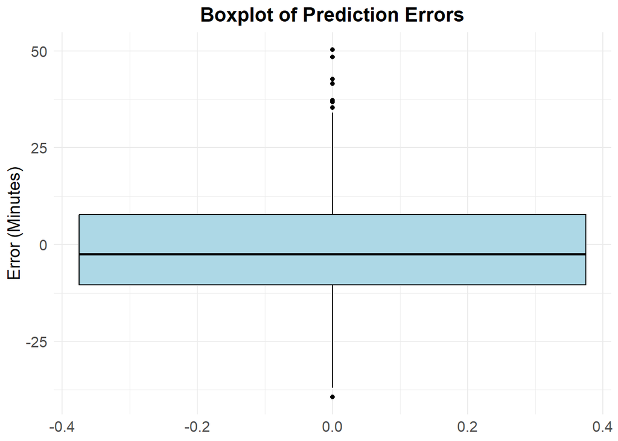

```r
#BOX-PLOT
ggplot(data.frame(error), aes(y = error)) +
  geom_boxplot(fill = "lightblue", color = "black") +
  labs(title = "Boxplot of Prediction Errors",
       y = "Error (Minutes)") +
  theme_minimal() +
  theme(plot.title = element_text(hjust = 0.5, size = 16, face = "bold"),
        axis.title = element_text(size = 14),
        axis.text = element_text(size = 12))
```

As we can observe, the prediction errors are centered around zero (indicating minimal errors) and exhibit low variability, resulting in predictions that are both reasonable and relatively accurate.

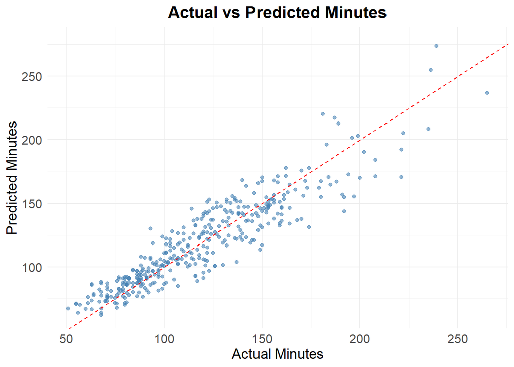

```r
# REAL VS PREDICTIONS
ggplot(ATP_matches_predict, aes(x = minutes, y = predicted_minutes)) +
  geom_point(color = "steelblue", alpha = 0.6) +
  geom_abline(slope = 1, intercept = 0, linetype = "dashed", color = "red") +
  labs(title = "Actual vs Predicted Minutes",
       x = "Actual Minutes",
       y = "Predicted Minutes") +
  theme_minimal() +
  theme(plot.title = element_text(hjust = 0.5, size = 16, face = "bold"),
        axis.title = element_text(size = 14),
        axis.text = element_text(size = 12))
```

As observed in the three previous graphs, our model appears to predict match duration quite accurately. This is primarily due to the high coefficient of determination achieved in our linear regression model, which reflects the strong dependency of our variables on the regressor variable, ‘minutes’.

### 3.1.5 Prediction intervals

```r
#PREDICTION INTERVALS

predictions_with_intervals <- predict(lm_model, newdata = ATP_matches_predict, interval = "prediction")
ATP_matches_predict <- cbind(ATP_matches_predict, predictions_with_intervals)
ATP_matches_predict$Lower <- predictions_with_intervals[, "lwr"]
ATP_matches_predict$Upper <- predictions_with_intervals[, "upr"]
```

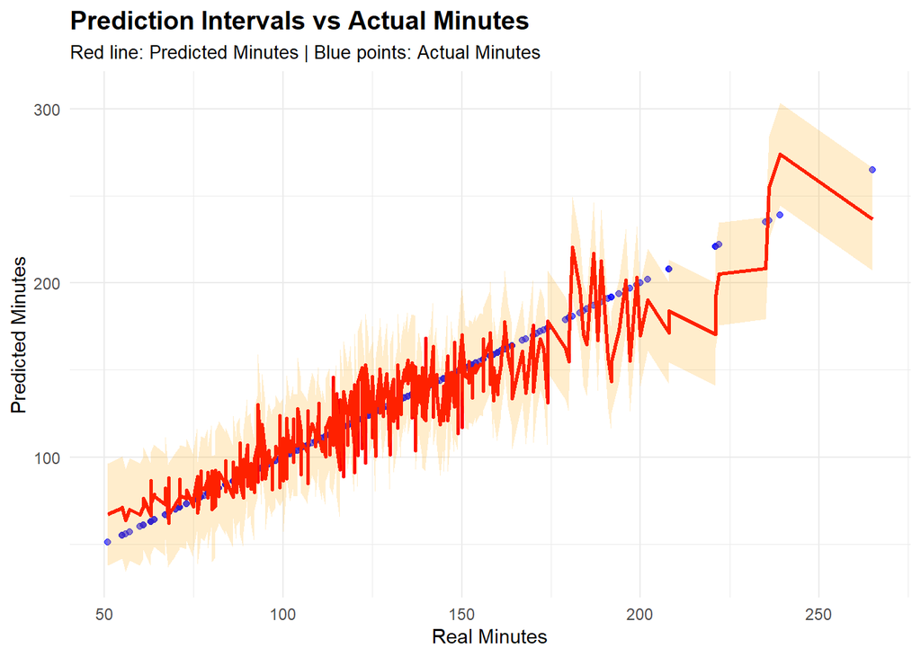

```r
ggplot(ATP_matches_predict, aes(x = minutes)) +
  geom_point(aes(y = minutes), color = "blue", size = 1.5, alpha = 0.6) +  # Puntos reales
  geom_line(aes(y = predicted_minutes), color = "red", size = 1) +  # Línea de predicción
  geom_ribbon(aes(ymin = lwr, ymax = upr), fill = "orange", alpha = 0.2) +  # Intervalos de predicción
  labs(
    title = "Prediction Intervals vs Actual Minutes",
    x = "Real Minutes",
    y = "Predicted Minutes",
    subtitle = "Red line: Predicted Minutes | Blue points: Actual Minutes"
  ) +
  theme_minimal() +
  theme(
    plot.title = element_text(size = 14, face = "bold"),
    plot.subtitle = element_text(size = 10)
  )
```

We can observe that our regression model performs well in predicting outcomes under normal match duration

### 3.1.6 Benchmark

We will use a Benchmark model to evaluate the performance of our model and determine its quality. In this case, we will employ the simplest benchmark approach: predicting using the mean of the observed values.

```r
# FILTER THE COLUMNS AND COMPUTE THE MEAN VALUE
ATP_matches_clean <- ATP_matches %>%
  filter(!is.na(minutes))
benchmark <- mean(ATP_matches_clean$minutes)
benchFit <- lm(ATP_matches$minutes ~ 1, data=ATP_matches)
pred.bench <- predict(benchFit, newdata=ATP_matches_predict)
```

```r
R2 <- 1 - (mean(abs(ATP_matches_clean$minutes - pred.bench)) / mean(ATP_matches_clean$minutes))
R2
```

```
## [1] 0.7294071
```

In this case, the R2 value obtained from the Benchmark model is significantly lower (over 20% worse) than that of our linear regression model. This suggests that our regression model is notably more accurate and explanatory, providing better predictive performance compared to the simplistic benchmark approach.

## 3.2 Model 2: Games won by each player

The next model we present focuses on analyzing the skill gap between the winning and losing players. To achieve this, we will examine the number of games won by the winner (winner_games) and the number of games won by the loser (loser_games). While this analysis can provide valuable insights for post-match evaluation, the more compelling challenge would be predicting the outcome of a match before it is played. Although this is a complex task that we may explore later in the project, for now, we will concentrate on this initial analysis.

### 3.2.1 Understanding the ‘target’ variable and the other variables

*Visualization of loser_games*

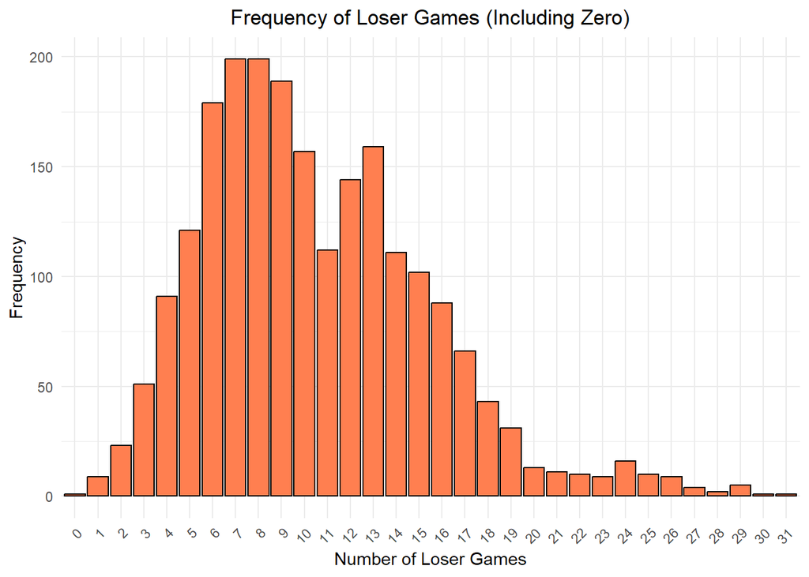

```r
#HISTOGRAM(loser_games)
min_loser_games <- 0
max_loser_games <- max(ATP_matches$loser_games, na.rm = TRUE)

ggplot(ATP_matches, aes(x = factor(loser_games, levels = min_loser_games:max_loser_games))) +
  geom_bar(fill = "coral", color = "black") +
  labs(
    title = "Frequency of Loser Games (Including Zero)",
    x = "Number of Loser Games",
    y = "Frequency"
  ) +
  scale_x_discrete(drop = FALSE) +
  theme_minimal() +
  theme(
    plot.title = element_text(hjust = 0.5),
    axis.text.x = element_text(angle = 45, hjust = 1)
  )
```

The resulting graph reflects a distribution that is approximately normal.

*Visualization of winner_games*

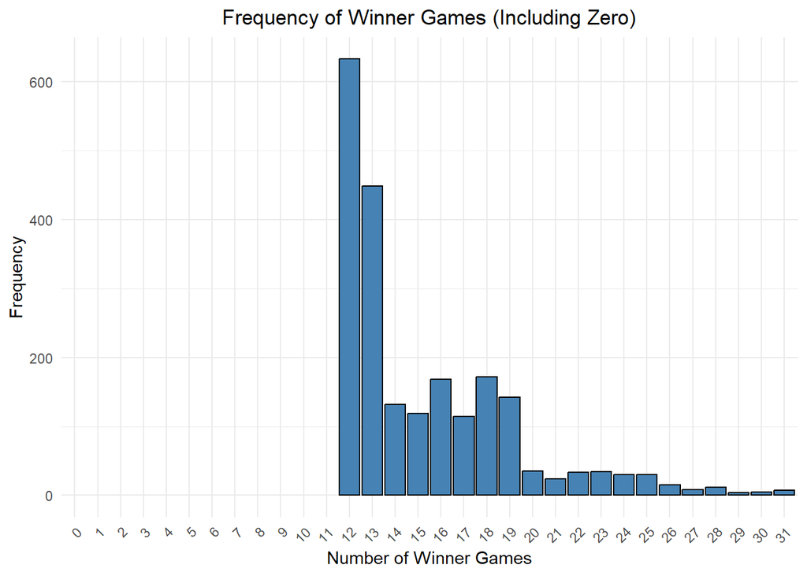

```
Why this graph is so strange compared to the previous one of loser games?
```

```r
#HISTOGRAM(winner_games)
    min_winner_games <- 0
    max_winner_games <- max(ATP_matches$winner_games, na.rm = TRUE)

    ggplot(ATP_matches, aes(x = factor(winner_games, levels = min_winner_games:max_winner_games))) +
      geom_bar(fill = "steelblue", color = "black") +
      labs(
        title = "Frequency of Winner Games (Including Zero)",
        x = "Number of Winner Games",
        y = "Frequency"
      ) +
      scale_x_discrete(drop = FALSE) +
      theme_minimal() +
      theme(
        plot.title = element_text(hjust = 0.5),
        axis.text.x = element_text(angle = 45, hjust = 1)
      )
```

**Explanation:** The reason for this is that, when cleaning our data during the execution of the extract_games function, we only retained **fully completed** matches. For a match to be considered complete, the winner must have won at least 2 sets (or 3 sets in the case of a Grand Slam). Since a set requires a minimum of 12 games (6 per set), this means the winner’s total game count is at least 12. Consequently, the resulting graph displays a more irregular pattern compared to the following one.

*Correlation* Analysis of the correlation of the different variables

```r
#CORRELATION
# CORRELATION ANALYSIS - winner_games

# Define the variables for the analysis
variables <- c("winner_games", "winner_ht", "w_1stIn", "w_svpt", "winner_rank","loser_ht", "l_1stIn", "l_svpt", "loser_rank", "total_games")

# Select the relevant data from the ATP_matches dataset
numeric_data <- subset(ATP_matches, select = variables)

# Calculate the correlation matrix, using only complete cases (non-missing values)
cor_matrix <- cor(numeric_data, use = "complete.obs")

# Extract the correlation of 'winner_games' with other variables (excluding itself)
cor_winner_games <- cor_matrix["winner_games", -1] # Exclude 'winner_games' itself

# Convert the correlation data into a data frame for easier visualization
cor_df <- data.frame(variable = names(cor_winner_games), correlation = cor_winner_games)

# Print the correlation results
print(cor_df)
```

```
##                variable correlation
## winner_ht     winner_ht  0.05360409
## w_1stIn         w_1stIn  0.86059730
## w_svpt           w_svpt  0.89158916
## winner_rank winner_rank  0.01665761
## loser_ht       loser_ht  0.07313271
## l_1stIn         l_1stIn  0.85961900
## l_svpt           l_svpt  0.89380794
## loser_rank   loser_rank -0.05966947
## total_games total_games  0.94888920
```

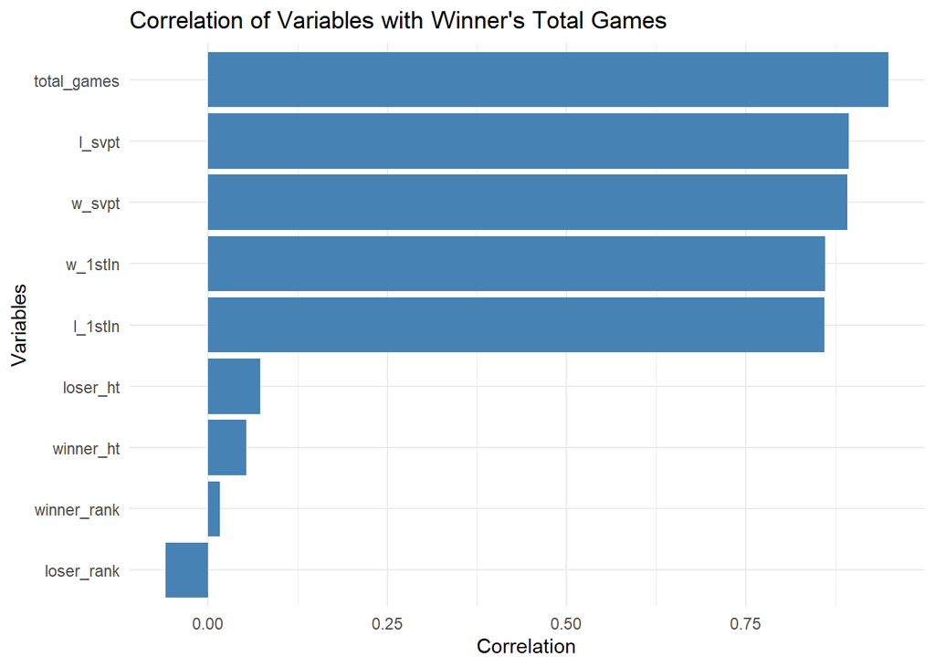

```r
# Plot the correlations in a bar chart
ggplot(cor_df, aes(x = reorder(variable, correlation), y = correlation)) +
  geom_bar(stat = "identity", fill = "steelblue") +
  coord_flip() + # Flip the coordinates for better readability
  labs(title = "Correlation of Variables with Winner's Total Games",
       x = "Variables", y = "Correlation") +
  theme_minimal()
```

**Explanation:** As expected, the more games played during a match, the higher the number of games won by the winner. Additionally, there is a correlation between the number of first serves made by the player and the games won. This is logical, as a greater number of serves is inherently tied to the total number of games played, which directly influences the winner’s game count.

```r
# CORRELATION ANALYSIS - loser_games

# Define the variables for the analysis
variables <- c("loser_games", "winner_ht", "w_1stIn", "w_svpt", "winner_rank",
               "loser_ht", "l_1stIn", "l_svpt", "loser_rank", "total_games")

# Select the relevant data from the ATP_matches dataset
numeric_data <- subset(ATP_matches, select = variables)

# Calculate the correlation matrix, using only complete cases (non-missing values)
cor_matrix <- cor(numeric_data, use = "complete.obs")

# Extract the correlation of 'loser_games' with other variables (excluding itself)
cor_loser_games <- cor_matrix["loser_games", -1]

# Convert the correlation data into a data frame for easier visualization
cor_df <- data.frame(variable = names(cor_loser_games), correlation = cor_loser_games)

# Print the correlation results
print(cor_df)
```

```
##                variable correlation
## winner_ht     winner_ht  0.04129259
## w_1stIn         w_1stIn  0.87913930
## w_svpt           w_svpt  0.92204024
## winner_rank winner_rank  0.06570264
## loser_ht       loser_ht  0.13381525
## l_1stIn         l_1stIn  0.87157724
## l_svpt           l_svpt  0.90785153
## loser_rank   loser_rank -0.10258713
## total_games total_games  0.96861855
```

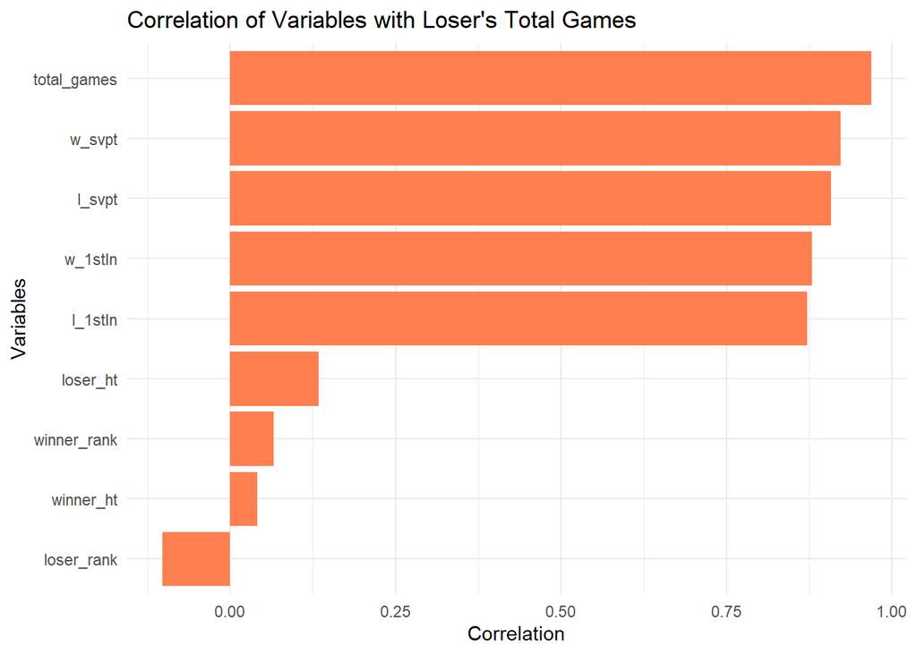

```r
# Plot the correlations in a bar chart
ggplot(cor_df, aes(x = reorder(variable, correlation), y = correlation)) +
  geom_bar(stat = "identity", fill = "coral") +
  coord_flip() + # Flip the coordinates for better readability
  labs(title = "Correlation of Variables with Loser's Total Games",
       x = "Variables", y = "Correlation") +
  theme_minimal()
```

**Explanation:** We obtain a very similar correlations compared to the winner_games.

### 3.2.2 Linear regression and Prediction

*Winner Games*

```r
#LINEAR REGRESSION (winner_games)

variables <- c("winner_games", "winner_ht", "w_1stIn", "w_svpt", "surface",
               "winner_hand", "winner_rank","loser_ht", "l_1stIn", "l_svpt","tourney_level", "loser_rank", "total_games")

numeric_data = subset(ATP_matches, select = c(variables))

# Fit the linear regression model

lm_model_winner <- lm(winner_games ~ ., data = numeric_data)

summary(lm_model_winner)
```

```
##
## Call:
## lm(formula = winner_games ~ ., data = numeric_data)
##
## Residuals:
##     Min      1Q  Median      3Q     Max
## -3.6752 -0.5203 -0.0985  0.4921  3.1997
##
## Coefficients:
##                  Estimate Std. Error t value Pr(>|t|)
## (Intercept)     6.1722339  0.8040453   7.676 2.66e-14 ***
## winner_ht       0.0041979  0.0031506   1.332  0.18289
## w_1stIn         0.0015942  0.0033777   0.472  0.63701
## w_svpt         -0.0032058  0.0029672  -1.080  0.28011
## surfaceGrass   -0.1954976  0.0608968  -3.210  0.00135 **
## surfaceHard    -0.0856326  0.0420935  -2.034  0.04206 *
## winner_handR   -0.0022595  0.0649764  -0.035  0.97226
## winner_rank    -0.0005657  0.0002665  -2.123  0.03391 *
## loser_ht       -0.0065515  0.0030441  -2.152  0.03152 *
## l_1stIn        -0.0021662  0.0033397  -0.649  0.51666
## l_svpt          0.0037050  0.0028176   1.315  0.18870
## tourney_levelG  3.0162468  0.0664549  45.388  < 2e-16 ***
## tourney_levelM -0.0043400  0.0468790  -0.093  0.92625
## loser_rank      0.0003785  0.0001948   1.943  0.05223 .
## total_games     0.3517154  0.0098544  35.691  < 2e-16 ***
## ---
## Signif. codes:  0 '***' 0.001 '**' 0.01 '*' 0.05 '.' 0.1 ' ' 1
##
## Residual standard error: 0.8167 on 1803 degrees of freedom
##   (348 observations deleted due to missingness)
## Multiple R-squared:  0.9564, Adjusted R-squared:  0.956
## F-statistic:  2822 on 14 and 1803 DF,  p-value: < 2.2e-16
```

Our R-squared value is 0.95 meaning that we can explain the 95% of the dataset

*Loser Games*

```r
#LINEAR REGRESSION (loser_games)

variables <- c("loser_games", "winner_ht", "w_1stIn", "w_svpt", "surface",
               "winner_hand", "winner_rank","loser_ht", "l_1stIn", "l_svpt","tourney_level", "loser_rank", "total_games")

numeric_data = subset(ATP_matches, select = c(variables))

# Fit the linear regression model

lm_model_loser <- lm(loser_games ~ ., data = numeric_data)

summary(lm_model_loser)
```

```
##
## Call:
## lm(formula = loser_games ~ ., data = numeric_data)
##
## Residuals:
##     Min      1Q  Median      3Q     Max
## -3.1997 -0.4921  0.0985  0.5203  3.6752
##
## Coefficients:
##                  Estimate Std. Error t value Pr(>|t|)
## (Intercept)    -6.1722339  0.8040453  -7.676 2.66e-14 ***
## winner_ht      -0.0041979  0.0031506  -1.332  0.18289
## w_1stIn        -0.0015942  0.0033777  -0.472  0.63701
## w_svpt          0.0032058  0.0029672   1.080  0.28011
## surfaceGrass    0.1954976  0.0608968   3.210  0.00135 **
## surfaceHard     0.0856326  0.0420935   2.034  0.04206 *
## winner_handR    0.0022595  0.0649764   0.035  0.97226
## winner_rank     0.0005657  0.0002665   2.123  0.03391 *
## loser_ht        0.0065515  0.0030441   2.152  0.03152 *
## l_1stIn         0.0021662  0.0033397   0.649  0.51666
## l_svpt         -0.0037050  0.0028176  -1.315  0.18870
## tourney_levelG -3.0162468  0.0664549 -45.388  < 2e-16 ***
## tourney_levelM  0.0043400  0.0468790   0.093  0.92625
## loser_rank     -0.0003785  0.0001948  -1.943  0.05223 .
## total_games     0.6482846  0.0098544  65.786  < 2e-16 ***
## ---
## Signif. codes:  0 '***' 0.001 '**' 0.01 '*' 0.05 '.' 0.1 ' ' 1
##
## Residual standard error: 0.8167 on 1803 degrees of freedom
##   (348 observations deleted due to missingness)
## Multiple R-squared:  0.9729, Adjusted R-squared:  0.9727
## F-statistic:  4629 on 14 and 1803 DF,  p-value: < 2.2e-16
```

### 3.2.3 Prediction

*Cleaning the predict database*

```r
#Cleaning the predict database
ATP_matches_predict$winner_hand <- as.factor(ATP_matches_predict$winner_hand)
ATP_matches_predict <- ATP_matches_predict[ATP_matches_predict$winner_hand != "U", ]
ATP_matches_predict<-ATP_matches_predict[ATP_matches_predict$tourney_level != "D", ]
```

*Winner Games*

```r
#PREDICTION

ATP_matches_predict$predicted_winner_games <- predict(lm_model_winner, newdata = ATP_matches_predict)

error = ATP_matches_predict$winner_games-ATP_matches_predict$predicted_winner_games
```

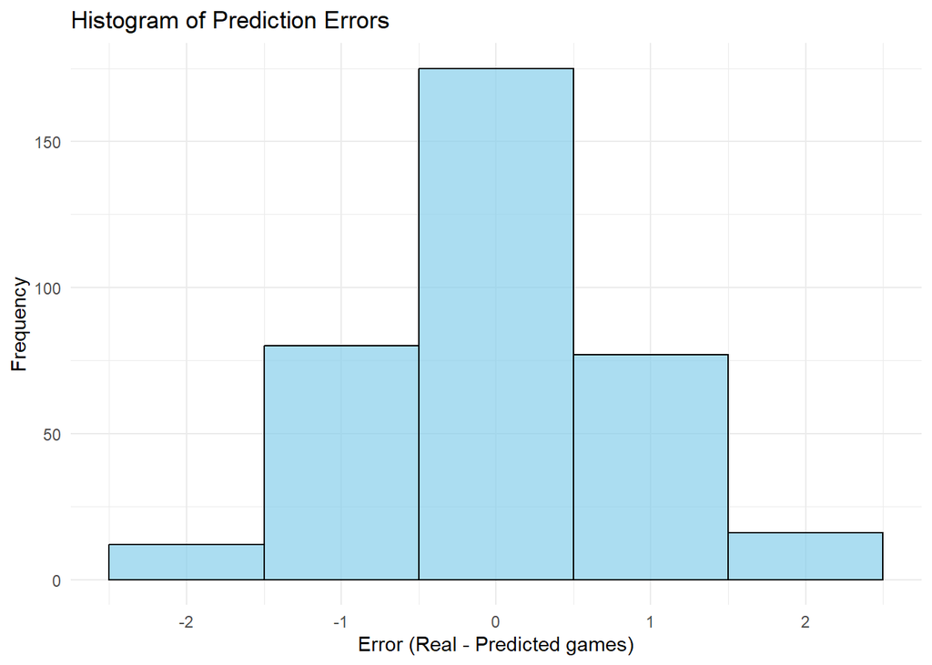

```r
#HISTOGRAM
ggplot(ATP_matches_predict, aes(x = error)) +
  geom_histogram(binwidth = 1, fill = "skyblue", color = "black", alpha = 0.7) +
  labs(title = "Histogram of Prediction Errors", x = "Error (Real - Predicted games)", y = "Frequency") +
  theme_minimal()
```

*Loser Games*

```r
#PREDICTION

ATP_matches_predict$predicted_loser_games <- predict(lm_model_loser, newdata = ATP_matches_predict)

error = ATP_matches_predict$loser_games-ATP_matches_predict$predicted_loser_games
```

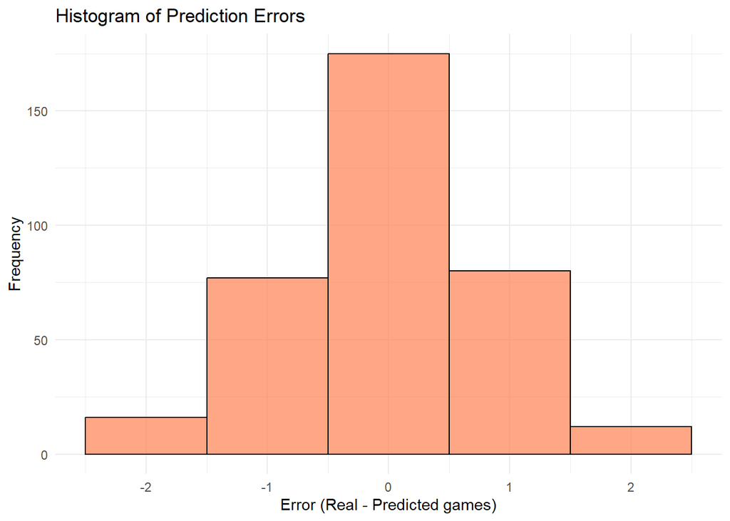

```r
#HISTOGRAM
ggplot(ATP_matches_predict, aes(x = error)) +
  geom_histogram(binwidth = 1, fill = "coral", color = "black", alpha = 0.7) +
  labs(title = "Histogram of Prediction Errors", x = "Error (Real - Predicted games)", y = "Frequency") +
  theme_minimal()
```

*Explanation of the predicting errors*

As expected, our prediction is highly accurate, as our R-squared coefficients are very close to 1. The model correctly predicts a large number of matches, with errors of just 1 or 2 games, which is a relatively low percentage. This is due to the fact that knowing the value of **‘total_games’** makes it quite easy to predict the number of games each player has won.

### 3.2.4 Predictive intervals

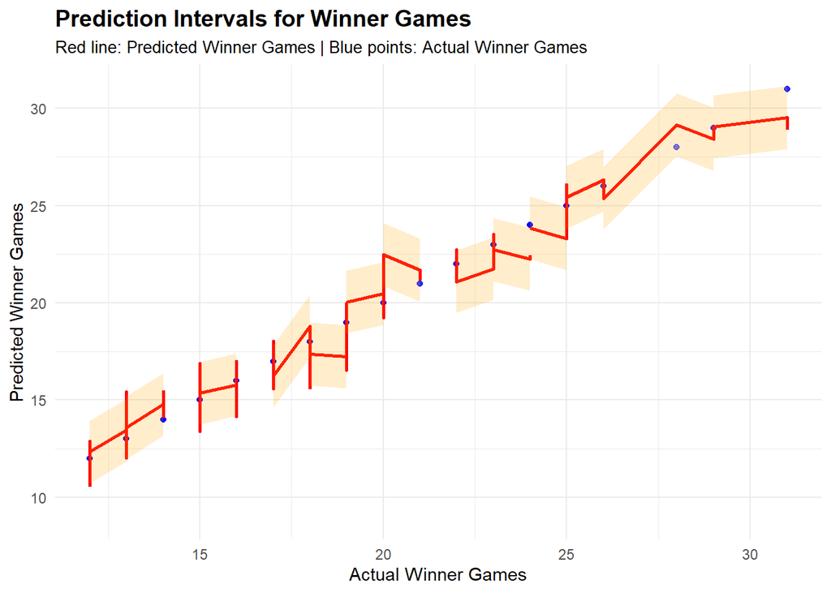

```r
# PREDICTION INTERVALS para winner_games

# Predicciones para 'winner_games' con intervalos
predictions_with_intervals_winner <- predict(lm_model_winner, newdata = ATP_matches_predict, interval = "prediction")

# Añadir las predicciones e intervalos al dataset
ATP_matches_predict$Lower_winner <- predictions_with_intervals_winner[, "lwr"]
ATP_matches_predict$Upper_winner <- predictions_with_intervals_winner[, "upr"]
ATP_matches_predict$Predicted_winner <- predictions_with_intervals_winner[, "fit"]  # Predicción de juegos ganados

# Gráfico para winner_games
ggplot(ATP_matches_predict, aes(x = winner_games)) +  # Usamos 'winner_games' como la variable real
  geom_point(aes(y = winner_games), color = "blue", size = 1.5, alpha = 0.6) +  # Puntos reales
  geom_line(aes(y = Predicted_winner), color = "red", size = 1) +  # Línea de predicción
  geom_ribbon(aes(ymin = Lower_winner, ymax = Upper_winner), fill = "orange", alpha = 0.2) +  # Intervalos de predicción
  labs(
    title = "Prediction Intervals for Winner Games",
    x = "Actual Winner Games",
    y = "Predicted Winner Games",
    subtitle = "Red line: Predicted Winner Games | Blue points: Actual Winner Games"
  ) +
  theme_minimal() +
  theme(
    plot.title = element_text(size = 14, face = "bold"),
    plot.subtitle = element_text(size = 10)
  )
```

Ultimately, this analysis is not the most relevant, as what we are primarily interested in predicting is the outcome of a match before it is played. The difference in the number of games played is less important when we already know the total number of games. Therefore, in the next section of the work, we will develop a logistic regression model to estimate and predict match outcomes based on the available characteristics.

### 3.2.5 Benchmark

We will use a Benchmark model to assess the performance and quality of our predictive model. For this purpose, we will adopt the simplest benchmark approach, as previously applied, by using the mean value of the games won by each player as the baseline prediction.

```r
# FILTER THE COLUMNS AND COMPUTE THE MEAN VALUE FOR WINNER_GAMES AND LOSER_GAMES
ATP_matches_clean <- ATP_matches %>%
  filter(!is.na(winner_games) & !is.na(loser_games))

# Calculate the mean benchmark for winner_games
benchmark_winner <- mean(ATP_matches_clean$winner_games)
benchFit_winner <- lm(winner_games ~ 1, data = ATP_matches_clean)
pred.bench_winner <- predict(benchFit_winner, newdata = ATP_matches_predict)

# Calculate the mean benchmark for loser_games
benchmark_loser <- mean(ATP_matches_clean$loser_games)
benchFit_loser <- lm(loser_games ~ 1, data = ATP_matches_clean)
pred.bench_loser <- predict(benchFit_loser, newdata = ATP_matches_predict)
```

```r
# Calculate R2 for winner_games
R2_winner <- 1 - (mean(abs(ATP_matches_clean$winner_games - pred.bench_winner)) / mean(ATP_matches_clean$winner_games))
print(paste("R2 for Winner Games:", R2_winner))
```

```
## [1] "R2 for Winner Games: 0.800556109270835"
```

```r
# Calculate R2 for loser_games
R2_loser <- 1 - (mean(abs(ATP_matches_clean$loser_games - pred.bench_loser)) / mean(ATP_matches_clean$loser_games))
print(paste("R2 for Loser Games:", R2_loser))
```

```
## [1] "R2 for Loser Games: 0.62502950807999"
```

**Explanation:**

In both cases, the R2 value obtained for the benchmark model is significantly worse than in our linear regression models. Therefore, we can conclude that our models are more explanatory and predictive compared to simply estimating based on the mean.

On the other hand, we observe that the R2 value for the benchmark of **loser_games** is considerably worse than that for **winner_games**. This discrepancy arises because the **loser_games** variable exhibits much higher variability compared to **winner_games**. As a result, the accuracy of predictions using the mean as the benchmark is substantially lower for **loser_games**.

# 4 GLM

In this section, we will work with two generalized linear models. The first model will focus on analyzing and predicting the number of Aces (direct serves that the opponent cannot touch), with a particular emphasis on exploring the relationship between a player’s height and their serving performance. The second model, which is the most crucial part of this work, is the logistic regression model. This model will be used to predict the outcome of a tennis match based on the available characteristics of the players and the match conditions.

## 4.1 Model 3: Ace’s

One of the most notable features of tennis is the number of Aces (serves that the opponent fails to touch, resulting in direct points) a player can achieve. In this analysis, we will examine the correlation between factors such as height, court surface type, the percentage of first serves successfully made, the number of serves executed during a match, among others. The main hypotheses are as follows: it is expected that height plays a significant role, as taller players can generate more power and accuracy in their serve, thereby increasing the likelihood of hitting an Ace. Additionally, the type of surface is anticipated to influence this probability, with grass courts being particularly favorable for Aces, as the faster bounce of the ball facilitates their occurrence.

### 4.1.1 Understanding the ‘target’ variable and the other variables

*Visualization of Aces*

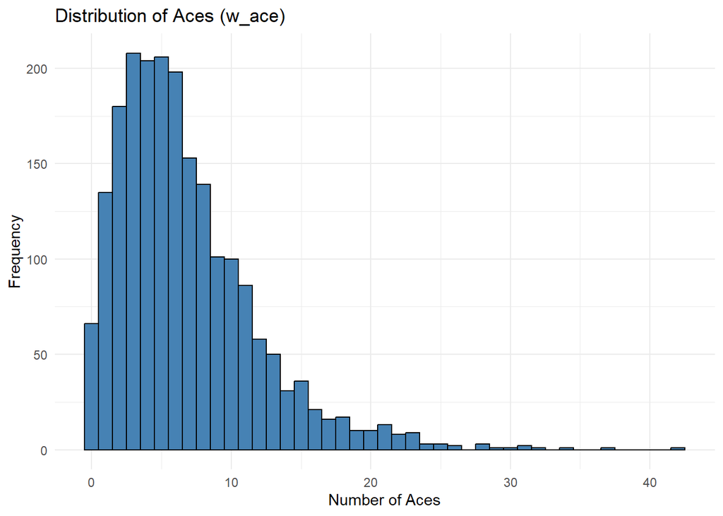

```r
#VISUALIZE THE NUMBER OF ACE'S OF THE WINNING PLAYER
ggplot(ATP_matches, aes(x = w_ace)) +
  geom_histogram(binwidth = 1, fill = "steelblue", color = "black") +
  labs(title = "Distribution of Aces (w_ace)", x = "Number of Aces", y = "Frequency") +
  theme_minimal()
```

*Visualization of Aces per surface*

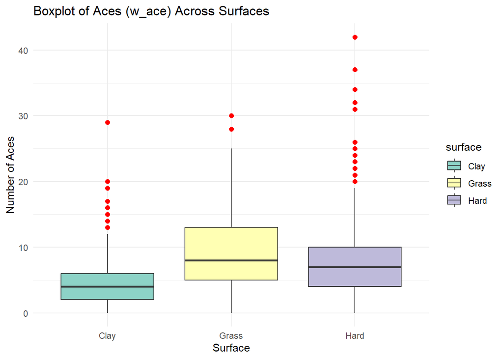

```r
# NUBER OF ACE'S PER SURFACE
ggplot(ATP_matches, aes(x = factor(surface), y = w_ace, fill = surface)) +
  geom_boxplot(outlier.colour = "red", outlier.shape = 16, outlier.size = 2) +
  labs(
    title = "Boxplot of Aces (w_ace) Across Surfaces",
    x = "Surface",
    y = "Number of Aces"
  ) +
  theme_minimal() +
  scale_fill_brewer(palette = "Set3")
```

As we have mentioned several times throughout the work, grass courts are faster, which encourages a higher number of aces. In contrast, clay courts are slower, leading to a lower number of aces due to the reduced ball speed, making it easier for players to return the ball.

*Correlation with some variables*

```r
#CORRELATION

variables <- c("w_ace", "winner_ht", "w_1stIn", "w_svpt", "winner_rank")
numeric_data = subset(ATP_matches, select = c(variables))

# Calculate correlation matrix
cor_matrix <- cor(numeric_data, use = "complete.obs")

# Extract correlation of 'minutes' with other variables
cor_ace <- cor_matrix["w_ace", -1] # Exclude 'minutes' itself

# Convert to a data frame for visualization
cor_df <- data.frame(variable = names(cor_ace), correlation = cor_ace)

# View the correlation data frame
print(cor_df)
```

```
##                variable correlation
## winner_ht     winner_ht  0.39427289
## w_1stIn         w_1stIn  0.34765659
## w_svpt           w_svpt  0.36186175
## winner_rank winner_rank  0.02820252
```

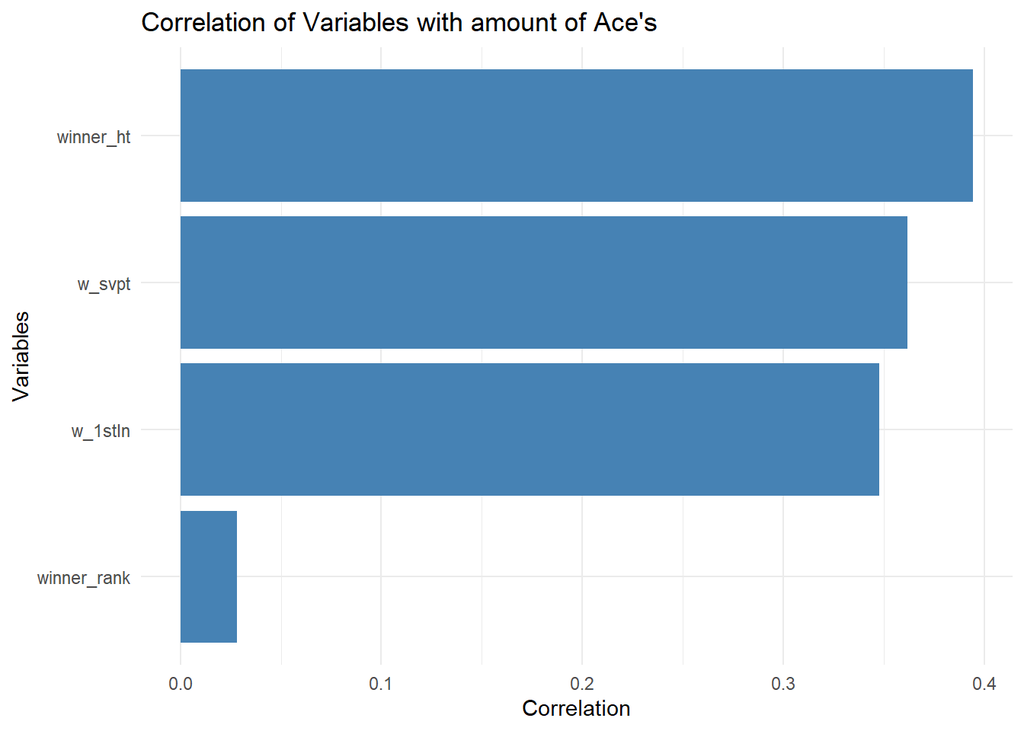

```r
# Plot correlations
ggplot(cor_df, aes(x = reorder(variable, correlation), y = correlation)) +
  geom_bar(stat = "identity", fill = "steelblue") +
  coord_flip() +
  labs(title = "Correlation of Variables with amount of Ace's",
       x = "Variables", y = "Correlation") +
 theme_minimal()
```

**Observation:** Before conducting the analysis, I want to highlight that the variable w_1stIn may not be particularly relevant. Successfully landing a high number of first serves does not necessarily imply an increase in the ace percentage, as these serves might lack the speed or precision required to achieve an ace.

### 4.1.2 Generalized linear model

```r
#GENERALIZED LINEAR MODEL USING THE POISSON DISTRIBUTION

variables <- c( "w_ace","winner_ht", "w_1stIn", "w_svpt", "surface","winner_hand", "winner_rank")
numeric_data = subset(ATP_matches, select = c(variables))

# Fit the regression model (Gamma)

poisson_model <- glm(w_ace +1~ ., data = numeric_data, family = poisson(link = "log"))

summary(poisson_model)
```

```
##
## Call:
## glm(formula = w_ace + 1 ~ ., family = poisson(link = "log"),
##     data = numeric_data)
##
## Coefficients:
##                Estimate Std. Error z value Pr(>|z|)
## (Intercept)  -5.9166535  0.2442521 -24.224  < 2e-16 ***
## winner_ht     0.0375287  0.0013064  28.727  < 2e-16 ***
## w_1stIn      -0.0024717  0.0013557  -1.823 0.068265 .
## w_svpt        0.0083484  0.0009109   9.165  < 2e-16 ***
## surfaceGrass  0.4935014  0.0234336  21.060  < 2e-16 ***
## surfaceHard   0.4213113  0.0187696  22.446  < 2e-16 ***
## winner_handR  0.0397575  0.0284137   1.399 0.161742
## winner_rank   0.0003373  0.0001008   3.347 0.000818 ***
## ---
## Signif. codes:  0 '***' 0.001 '**' 0.01 '*' 0.05 '.' 0.1 ' ' 1
##
## (Dispersion parameter for poisson family taken to be 1)
##
##     Null deviance: 5920.9  on 1983  degrees of freedom
## Residual deviance: 3485.3  on 1976  degrees of freedom
##   (182 observations deleted due to missingness)
## AIC: 10874
##
## Number of Fisher Scoring iterations: 4
```

**Explanation of the main results obtained**

**Height:** The analysis reveals that height is highly significant ( **p <2e-16**).

**Surface:** As previously mentioned, clay courts are the slowest surface, which increases the difficulty of making aces. This is why the type of surface plays a significant role. Matches on grass and hard courts show up have more aces compared to clay courts, with a highly significant p-value (**< 2e-16**).

### 4.1.3 Individual effects of some variables

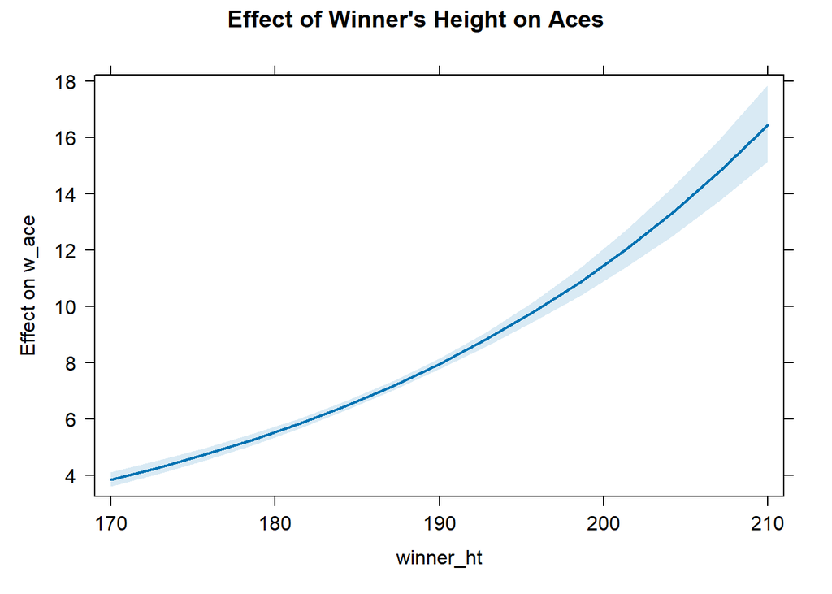

```r
#EFFECT OF THE HEIGHT
plot(effect("winner_ht", glm(w_ace + 1 ~ ., data = subset(ATP_matches, select = c("w_ace", "winner_ht", "w_1stIn", "w_svpt", "surface", "winner_hand", "winner_rank")), family = Gamma(link = "log"))), ci.style = "band", rescale.axis = FALSE, multiline = TRUE, ylab = "Effect on w_ace", rug = FALSE, main = "Effect of Winner's Height on Aces")
```

As expected, higher players tent to hit more Ace’s compared to those players that aren’t tall enough.

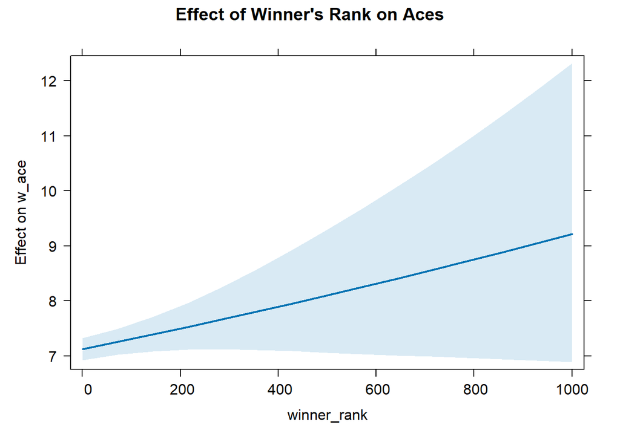

```r
#EFFECT OF THE RANK
plot(effect("winner_rank", glm(w_ace + 1 ~ ., data = subset(ATP_matches, select = c("w_ace", "winner_ht", "w_1stIn", "w_svpt", "surface", "winner_hand", "winner_rank")), family = Gamma(link = "log"))), ci.style = "band", rescale.axis = FALSE, multiline = TRUE, ylab = "Effect on w_ace", rug = FALSE, main = "Effect of Winner's Rank on Aces")
```

**Explanation:** We can observe that higher-ranked players (those with lower numerical ranks) tend to hit approximately 7 aces, which is not a particularly high number. For players with lower rankings, there is much more variability, as this group includes players with a wide range of playing styles.

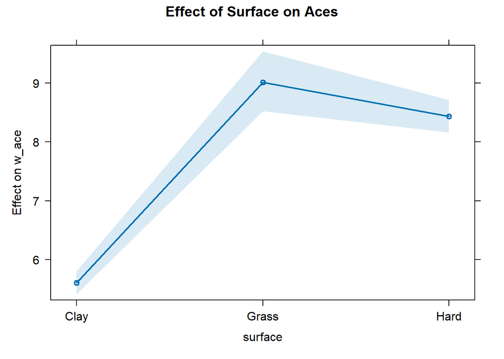

```r
#EFFECT OF THE SURFACE
plot(effect("surface", glm(w_ace + 1 ~ ., data = subset(ATP_matches, select = c("w_ace", "winner_ht", "w_1stIn", "w_svpt", "surface", "winner_hand", "winner_rank")), family = Gamma(link = "log"))), ci.style = "band", rescale.axis = FALSE, multiline = TRUE, ylab = "Effect on w_ace", rug = FALSE, main = "Effect of Surface on Aces")
```

**Explanation:** As we anticipated, the expected number of aces on clay courts is lower because the conditions make the game slower, allowing for easier returns of serve. In contrast, faster surfaces, such as grass courts, favor more aces since the ball travels quicker, making it harder for players to return the serve.